# BDCC Lab Report

```python
%%HTML
<script src="require.js"></script>
```

```python
from IPython.display import display, HTML
HTML(
    """
    <script
        src='https://cdnjs.cloudflare.com/ajax/libs/jquery/2.0.3/jquery.min.js'>
    </script>
    <script>
        code_show=true;
        function code_toggle() {
        if (code_show){
        $('div.jp-CodeCell > div.jp-Cell-inputWrapper').hide();
        } else {
        $('div.jp-CodeCell > div.jp-Cell-inputWrapper').show();
        }
        code_show = !code_show
        }
        $( document ).ready(code_toggle);
    </script>
    <form action='javascript:code_toggle()'>
        <input type="submit" value='Click here to toggle on/off the raw code.'>
    </form>
    """
)
```

```python
# Import libraries
import numpy as np
import pandas as pd
import os
import re
import matplotlib.pyplot as plt
import matplotlib.cm as cm
from statsmodels.tsa.seasonal import seasonal_decompose
from pymannkendall import original_test
from sklearn.preprocessing import StandardScaler as StandardScalerSklearn
from sklearn import mixture
from pyspark.sql import SparkSession
from pyspark.sql.functions import year, month, col, min, max, avg, udf, sum
from pyspark.sql.types import DoubleType
from pyspark.ml.feature import StandardScaler as StandardScalerSpark
from pyspark.ml.feature import VectorAssembler
from pyspark.ml.stat import Correlation
import seaborn as sns
import calendar
import base64
from io import BytesIO
import xarray as xr
import dask

# Set display options
pd.set_option('display.max_columns', None)

# Set xarray options
xr.set_options(keep_attrs=True)

# Set dask scheduler
dask.config.set(scheduler='threads')

# Suppress specific warnings
import warnings
warnings.filterwarnings('ignore',
                        message='The get_cmap function was deprecated');
```

```python
# Set helper functions
def plot_to_html(alt_text):
    """
    Display the current figure as a centered html image

    Parameters
    ----------
    alt_text: str
        The alternative text for the image displayed
    """
    fig = plt.gcf()
    buf = BytesIO()
    plt.savefig(buf, format='png')
    plt.close()
    fig = base64.b64encode(buf.getvalue()).decode('utf-8')
    html = f'''<div style="text-align: center;">
                   <img src="data:…"
                        alt="{alt_text}"/>
                   </div>'''
    display(HTML(html))

def plot_trend(df, feature, fig_num):
    """
    Plot the trend of a given feature using seasonal decomposition

    Parameters
    ----------
    df : DataFrame
        The DataFrame containing the time series data.
    feature : str
        The name of the feature to plot.
    fig_num : int
        The figure number for identifying the plot.
    """
    result_sd = seasonal_decompose(df[feature],
                                   model='additive',
                                   period=365)

    fig, axs = plt.subplots(2, 1, figsize=(12, 7))
    axs[0].plot(df['time'], df[feature], label='Original',
                c='#2B547E', lw=0.75)
    axs[0].legend(loc='upper left')
    axs[0].set_ylabel(f'{feature.upper()}')
    axs[0].grid(axis='y')
    axs[1].plot(df['time'], result_sd.trend, label='Trend',
               c='#2B547E', lw=0.75)
    axs[1].legend(loc='upper left')
    axs[1].set_ylabel('Trend')
    axs[1].grid(axis='y')
    fig.suptitle(f'Figure {fig_num}. Trend of {feature.upper()} '
                 f'from Seasonal Decomposition')
    plt.xlabel('Year')
    plot_to_html(f'Figure {fig_num}. Trend of {feature.upper()} '
                 f'from Seasonal Decomposition')

def plot_cubic_poly_mk(df, feature, fig_num):
    """
    Plot cubic polynomial line fit for a feature and perform Mann-Kendall test

    Parameters
    ----------
    df : DataFrame
        The DataFrame containing the time series data.
    feature : str
        The name of the feature to analyze.
    fig_num : int
        The figure number for identifying the plot.
    """
    mk_result = original_test(df[feature])
    mk_text = (f'Mann-Kendall P-Value: {mk_result.p:.3f}, '
               f'Trend: {mk_result.trend}')

    plt.figure(figsize=(10, 6))
    plt.plot(df['time'],
             df[feature],
             label='Original',
             color='#2B547E',
             lw=0.75)
    plt.plot(df['time'],
             np.poly1d(np.polyfit(df.index,
                                  df[feature],
                                  2))(df.index),
             label='Cubic Polynomial Line Fit',
             color='r')
    plt.title(f'Figure {fig_num}. Cubic Polynomial Line Fit for '
              f'{feature.upper()}')
    plt.xlabel('Year')
    plt.ylabel(f'{feature.upper()}')
    plt.legend(loc='upper right')
    plt.grid(axis='y')
    plt.text(0, -0.136, mk_text, transform=plt.gca().transAxes, fontsize=9.5)
    plot_to_html(f'Figure {fig_num}. Cubic Polynomial Line Fit for '
                 f'{feature.upper()}')

def calculate_heat_idx(t, rh):
    """
    Calculate the heat index based on temperature and relative humidity

    Parameters
    ----------
    t : float
        The temperature in degrees Farenheit.
    rh : float
        The relative humidity as a percentage.

    Returns
    -------
    float
        The calculated heat index.
    """
    heat_idx = (-42.379 +
                (2.04901523 * t) +
                (10.14333127 * rh) +
                (-0.22475541 * t * rh) +
                (-6.83783e-3 * t**2) +
                (-5.481717e-2 * rh**2) +
                (1.22874e-3 * (t**2) * rh) +
                (8.5282e-4 * t * (rh**2)) +
                (-1.99e-6 * (t**2) * (rh**2))
               )
    return heat_idx

def apply_header_style(df):
    """
    Apply a custom style to the DataFrame's column headers.

    Parameters
    ----------
    df : DataFrame
        The input DataFrame.
    """
    return df.style.set_table_styles([
        {'selector': 'thead',
         'props': [('background-color', '#de6f54'), ('color', 'white')]}
    ])
```

[figure not shown]

1. Abstract

2. Problem Statement

3. Motivation

4. Data Source

5. Data Exploration

6. Methodology Overview

7. Data Preparation

8. Descriptive Statistics

9. Results and Discussion

10. Conclusion

11. Recommendations

12. References

# 1. Abstract

This study delves into the temperature trends of the Philippines over a 20-year span, stemming from the recent alarming high temperatures reported in the local news during April 2024. The motivation behind this research arises from a growing concern regarding the perceived increase in temperatures and its various impacts on agriculture, economy, health, and daily activities.

To conduct this analysis, GEOS and MERRA data were utilized to analyze daily temperature data. The methodology adopted for this study encompasses several key steps, including data preparation and descriptive statistics. The data was filtered and transformed through Xarray before being saved in Parquet files and loaded into Spark DataFrames for further analysis. Descriptive statistics techniques such as geographical heat maps, yearly temperature comparisons, and time series analysis were employed to gain insights into the temperature patterns. Supplementary analysis involving anomaly detection and correlation matrix were also performed.

The findings of the study reveal a progressive increase in temperatures across ths span of two decades, with April 2024 standing out as one of the outliers, with exceptionally high temperatures and deviating relative humidity. Furthermore, the analysis indicates a correlation between minimum temperature, cooling degree days, among others and the heat index, suggesting a complex interplay of factors influencing temperature trends in the region.

Based on these insights, the study can be utilized to inform policy and planning decisions to mitigate the impacts of climate change in the Philippines. Recommendations for future research include extending the analysis beyond the 20-year timeframe, incorporating hourly data for a more detailed analysis, and exploring the use of Sedona with PySpark for geospatial analysis. These enhancements could further enhance the methodology and findings, providing a more comprehensive understanding of long-term climate trends in the region.

# 2. Problem Statement

[figure not shown]

Over the past recent weeks during late April to early May 2024, the Philippine news cycle has been bombarded with headlines on the unbearable temperatures, high heat indexes across regions, and disruption of general daily life. One particularly unusual phenomenon this year is the suspension of classes due to the heat. However, the Philippines has experienced high heat during the El Nino seasons in the past, without disruption to classes. There is a general sentiment that this year in particular feels especially hotter in comparison to the previous years, and that temperatures have been gradually rising over the years. Therefore, the problem statement is posed:

**How has temperatures in the Philippines changed over the decades, and is it really hotter now versus before?**

The study aims to answer this question through descriptive analytics of Philippine thermal data over the past two decades, by observing trends, or distinct anomalies from historical data.

# 3. Motivation

While the country annually experiences the El Nino season and the high temperatures that come with it, there is a growring sense of urgency over the recent years due to the increasing impact of high heat on disrupting daily life.

Issues can include affected agricultural production due to drought, which can have far-reaching effects on the economy outside of the direct households that rely on the industry for their livelihood. One such effect are risk of increasing food prices due to lower food supplies. In addition to agricultural and economic impacts, the high heat can bring about health issues such as heat exhaustion or heat stroke. Due to this risk in health, the high temperatures has recently brought about the disruption of daily activities such as the suspension of classes.

The motivation of the study is to analyze previous historical data, using recent real-time information only delayed by a few days to determine trends or patterns that can substantiate and support this growing concern. This information can **help policymakers, urban planners, and local governments understand the issue, driving them towards making data-driven decisions** on how to adapt to the current trend of the climate.

# 4. Data Source

## 4.1 Source Description

The data used for the study is originally sourced from the NASA Prediction of Worldwide Energy Resources (POWER) Project, a NASA Applied Sciences program that provides accessibility for NASA Earth Observations (EO), and includes hourly, daily, monthly and yearly solar-based and meteorological data (NASA, n.d.).

The data is made available via the Asian Institute of Management (AIM) Jojie-collected public datasets under the directory `/mnt/data/public/power-datastore/`, and is stored as netCDF(`.nc`) formatted files, which can initially be accessed for viewing via `xarray`.

The study will focus on the analysis of the meteorological data, found in the following files:

- Modern Era Retrospective-Analysis for Research and Applications (MERRA-2), or **MERRA** for short.
- Forward Processing – Instrument Teams (FP-IT) GEOS 5.12.4, or **GEOS** for short.

## 4.2 Assumptions and Limitations of the Study

1. The analysis of the study covers a **20-year** time period.

   The scope of the study is limited to 20 years as part of the motivation for the study is to explore the common public perception that it has gotten increasingly and significantly hotter over the past few years. Therefore, 20 years are selected to capture sufficient long-term variability, but limiting the scope to more recent data.
2. The **GEOS** data is used in place of the unavailability of **MERRA** data.

   Universal Time Coordinated (UTC) is the standard measure of time used across the world, while Local Solar Time (LST) is based on a fifteen degrees swath that represents solar noon at the middle longitude of the swath, stated in the NASA POWER FAQ (NASA Langley Research Center, n.d.). LST is based on the positioning of the Sun and can be variable across different regions due to the irregularity of the Earth's orbit. UTC is more appropriate as the time measurement for the study due to its consistency, and standardized use globally and across several industries.

# 5. Data Exploration

The raw GEOS and MERRA datasets can be accessed using `xarray` Python package, as is it based on the netCDF(`.nc`) data model originating from geosciences (Hoyer et al., n.d.). The first few data entries are viewed to gain a better understanding on the two datasets.

## 5.1 GEOS Data

```python
file_geos = ('/mnt/data/public/power-datastore/v9/daily/2024/04/'
             'power_901_daily_20240401_geos5124_utc.nc')
data_geos = xr.open_mfdataset(file_geos,
                              parallel=True,
                              chunks={'time': 'auto',
                                      'lat': 'auto',
                                      'lon': 'auto'},
                              engine='netcdf4')
data_geos = data_geos.load()
```

##### Table 1. Snapshot of GEOS Data

```python
apply_header_style((data_geos
 .head(3)
 .to_dataframe()
 .sort_index(axis=1)
 .rename(columns=str.lower)
))
```

| lon | lat | time | cdd0 | cdd10 | cdd18_3 | disph | frost_days | frseaice | hdd0 | hdd10 | hdd18_3 | prectotcorr | ps | qv10m | qv2m | rh2m | rhoa | t10m | t10m_max | t10m_min | t10m_range | t2m | t2mdew | t2mwet | t2m_max | t2m_min | t2m_range | to3 | tqv | … |
| --- | --- | --- | --- | --- | --- | --- | --- | --- | --- | --- | --- | --- | --- | --- | --- | --- | --- | --- | --- | --- | --- | --- | --- | --- | --- | --- | --- | --- | --- | --- |
| -180.000000 | -90.000000 | 2024-04-01 00:00:00 | 0.000000 | 0.000000 | 0.000000 | 0.000000 | 1 days 00:00:00 | 0.000000 | 55.312500 | 65.312500 | 73.625000 | 0.000005 | 67546.000000 | 0.000000 | 0.000000 | 99.000000 | 1.075195 | 218.375000 | 219.375000 | 217.210938 | 2.164062 | 217.835938 | 217.757812 | 217.796875 | 218.757812 | 216.867188 | 1.882812 | 239.859375 | 0.476562 | … |
|  | -89.500000 | 2024-04-01 00:00:00 | 0.000000 | 0.000000 | 0.000000 | 0.000000 | 1 days 00:00:00 | 0.000000 | 56.250000 | 66.250000 | 74.562500 | 0.000006 | 66763.000000 | 0.000000 | 0.000000 | 98.625000 | 1.065430 | 217.789062 | 218.875000 | 216.460938 | 2.414062 | 217.000000 | 216.882812 | 216.945312 | 217.695312 | 216.054688 | 1.632812 | 243.523438 | 0.468750 | … |
|  | -89.000000 | 2024-04-01 00:00:00 | 0.000000 | 0.000000 | 0.000000 | 0.000000 | 1 days 00:00:00 | 0.000000 | 55.812500 | 65.812500 | 74.125000 | 0.000006 | 65639.312500 | 0.000000 | 0.000000 | 99.687500 | 1.043945 | 218.421875 | 219.546875 | 217.023438 | 2.531250 | 217.484375 | 217.460938 | 217.476562 | 218.015625 | 216.679688 | 1.328125 | 247.468750 | 0.460938 | … |
| -179.375000 | -90.000000 | 2024-04-01 00:00:00 | 0.000000 | 0.000000 | 0.000000 | 0.000000 | 1 days 00:00:00 | 0.000000 | 55.312500 | 65.312500 | 73.625000 | 0.000005 | 67546.000000 | 0.000000 | 0.000000 | 99.000000 | 1.075195 | 218.375000 | 219.375000 | 217.210938 | 2.164062 | 217.835938 | 217.757812 | 217.796875 | 218.757812 | 216.867188 | 1.882812 | 239.859375 | 0.476562 | … |
|  | -89.500000 | 2024-04-01 00:00:00 | 0.000000 | 0.000000 | 0.000000 | 0.000000 | 1 days 00:00:00 | 0.000000 | 56.250000 | 66.250000 | 74.562500 | 0.000006 | 66770.312500 | 0.000000 | 0.000000 | 98.625000 | 1.065430 | 217.781250 | 218.875000 | 216.398438 | 2.476562 | 216.992188 | 216.875000 | 216.937500 | 217.695312 | 216.054688 | 1.632812 | 243.546875 | 0.468750 | … |
|  | -89.000000 | 2024-04-01 00:00:00 | 0.000000 | 0.000000 | 0.000000 | 0.000000 | 1 days 00:00:00 | 0.000000 | 55.812500 | 65.812500 | 74.125000 | 0.000006 | 65650.000000 | 0.000000 | 0.000000 | 99.687500 | 1.043945 | 218.421875 | 219.546875 | 217.023438 | 2.531250 | 217.484375 | 217.460938 | 217.468750 | 218.015625 | 216.679688 | 1.328125 | 247.484375 | 0.468750 | … |
| -178.750000 | -90.000000 | 2024-04-01 00:00:00 | 0.000000 | 0.000000 | 0.000000 | 0.000000 | 1 days 00:00:00 | 0.000000 | 55.312500 | 65.312500 | 73.625000 | 0.000005 | 67546.000000 | 0.000000 | 0.000000 | 99.000000 | 1.075195 | 218.375000 | 219.375000 | 217.210938 | 2.164062 | 217.835938 | 217.757812 | 217.796875 | 218.757812 | 216.867188 | 1.882812 | 239.859375 | 0.476562 | … |
|  | -89.500000 | 2024-04-01 00:00:00 | 0.000000 | 0.000000 | 0.000000 | 0.000000 | 1 days 00:00:00 | 0.000000 | 56.250000 | 66.250000 | 74.562500 | 0.000006 | 66777.625000 | 0.000000 | 0.000000 | 98.562500 | 1.065430 | 217.757812 | 218.875000 | 216.398438 | 2.476562 | 216.992188 | 216.867188 | 216.929688 | 217.695312 | 216.054688 | 1.632812 | 243.554688 | 0.468750 | … |
|  | -89.000000 | 2024-04-01 00:00:00 | 0.000000 | 0.000000 | 0.000000 | 0.000000 | 1 days 00:00:00 | 0.000000 | 55.812500 | 65.812500 | 74.125000 | 0.000006 | 65662.625000 | 0.000000 | 0.000000 | 99.687500 | 1.044922 | 218.414062 | 219.546875 | 217.023438 | 2.531250 | 217.484375 | 217.453125 | 217.468750 | 218.015625 | 216.679688 | 1.328125 | 247.500000 | 0.468750 | … |

**Table 1.** displays a snapshot of a single day in the GEOS data.

The raw data for one GEOS daily file contains **207,936** rows representing data entries, and **55** columns representing features, with each data entry consisting of the corresponding day and longitude-latitude pair of the observed parameters. The dataset has three indexes, `lon`, `lat`, and `time` corresponding the the longitude and latitude coordinates of the location and date of observations for the listed parameters.

## 5.2 MERRA Data

```python
file_merra = ('/mnt/data/public/power-datastore/v9/daily/2024/03/'
              'power_901_daily_20240301_merra2_utc.nc')
data_merra = xr.open_mfdataset(file_merra,
                               parallel=True,
                               chunks={'time': 'auto',
                                       'lat': 'auto',
                                       'lon': 'auto'},
                               engine='netcdf4')
data_merra = data_merra.load()
```

##### Table 2. Snapshot of MERRA Data

```python
apply_header_style((data_merra
 .head(3)
 .to_dataframe()
 .sort_index(axis=1)
 .rename(columns=str.lower)
))
```

| lon | lat | time | cdd0 | cdd10 | cdd18_3 | disph | evland | evptrns | frost_days | frseaice | frsno | gwetprof | gwetroot | gwettop | hdd0 | hdd10 | hdd18_3 | pbltop | precsno | precsnoland | prectotcorr | ps | qv10m | qv2m | rh2m | rhoa | slp | snodp | t10m | … |
| --- | --- | --- | --- | --- | --- | --- | --- | --- | --- | --- | --- | --- | --- | --- | --- | --- | --- | --- | --- | --- | --- | --- | --- | --- | --- | --- | --- | --- | --- | --- |
| -180.000000 | -90.000000 | 2024-03-01 00:00:00 | 0.000000 | 0.000000 | 0.000000 | 0.000000 | nan | nan | 1 days 00:00:00 | 0.000000 | nan | nan | nan | 1.000000 | 49.750000 | 59.750000 | 68.062500 | 66904.000000 | 0.000001 | nan | 0.000001 | 67490.125000 | 0.000061 | 0.000061 | 99.500000 | 1.042969 | 98131.625000 | nan | 224.351562 | … |
|  | -89.500000 | 2024-03-01 00:00:00 | 0.000000 | 0.000000 | 0.000000 | 0.000000 | nan | nan | 1 days 00:00:00 | 0.000000 | nan | nan | nan | 1.000000 | 51.312500 | 61.312500 | 69.625000 | 66257.375000 | 0.000001 | nan | 0.000001 | 66779.375000 | 0.000061 | 0.000061 | 99.750000 | 1.037109 | 98141.437500 | nan | 223.265625 | … |
|  | -89.000000 | 2024-03-01 00:00:00 | 0.000000 | 0.000000 | 0.000000 | 0.000000 | nan | nan | 1 days 00:00:00 | 0.000000 | nan | nan | nan | 1.000000 | 52.000000 | 62.000000 | 70.312500 | 65241.000000 | 0.000001 | nan | 0.000001 | 65733.250000 | 0.000061 | 0.000000 | 99.937500 | 1.023438 | 98099.500000 | nan | 222.750000 | … |
| -179.375000 | -90.000000 | 2024-03-01 00:00:00 | 0.000000 | 0.000000 | 0.000000 | 0.000000 | nan | nan | 1 days 00:00:00 | 0.000000 | nan | nan | nan | 1.000000 | 49.750000 | 59.750000 | 68.062500 | 66904.000000 | 0.000001 | nan | 0.000001 | 67490.125000 | 0.000061 | 0.000061 | 99.500000 | 1.042969 | 98131.625000 | nan | 224.351562 | … |
|  | -89.500000 | 2024-03-01 00:00:00 | 0.000000 | 0.000000 | 0.000000 | 0.000000 | nan | nan | 1 days 00:00:00 | 0.000000 | nan | nan | nan | 1.000000 | 51.312500 | 61.312500 | 69.625000 | 66265.687500 | 0.000001 | nan | 0.000001 | 66786.500000 | 0.000061 | 0.000061 | 99.750000 | 1.037109 | 98141.812500 | nan | 223.265625 | … |
|  | -89.000000 | 2024-03-01 00:00:00 | 0.000000 | 0.000000 | 0.000000 | 0.000000 | nan | nan | 1 days 00:00:00 | 0.000000 | nan | nan | nan | 1.000000 | 52.000000 | 62.000000 | 70.312500 | 65252.000000 | 0.000001 | nan | 0.000001 | 65743.937500 | 0.000061 | 0.000000 | 99.937500 | 1.023438 | 98099.937500 | nan | 222.750000 | … |
| -178.750000 | -90.000000 | 2024-03-01 00:00:00 | 0.000000 | 0.000000 | 0.000000 | 0.000000 | nan | nan | 1 days 00:00:00 | 0.000000 | nan | nan | nan | 1.000000 | 49.750000 | 59.750000 | 68.062500 | 66904.000000 | 0.000001 | nan | 0.000001 | 67490.125000 | 0.000061 | 0.000061 | 99.500000 | 1.042969 | 98131.625000 | nan | 224.351562 | … |
|  | -89.500000 | 2024-03-01 00:00:00 | 0.000000 | 0.000000 | 0.000000 | 0.000000 | nan | nan | 1 days 00:00:00 | 0.000000 | nan | nan | nan | 1.000000 | 51.312500 | 61.312500 | 69.625000 | 66273.375000 | 0.000001 | nan | 0.000001 | 66793.750000 | 0.000061 | 0.000061 | 99.750000 | 1.037109 | 98142.187500 | nan | 223.257812 | … |
|  | -89.000000 | 2024-03-01 00:00:00 | 0.000000 | 0.000000 | 0.000000 | 0.000000 | nan | nan | 1 days 00:00:00 | 0.000000 | nan | nan | nan | 1.000000 | 52.000000 | 62.000000 | 70.312500 | 65262.375000 | 0.000001 | nan | 0.000001 | 65754.625000 | 0.000061 | 0.000000 | 99.937500 | 1.023438 | 98100.312500 | nan | 222.750000 | … |

**Table 2.** displays a snapshot of a single day in the MERRA data.

Similar to the GEOS daily file, a MERRA daily file contains 207,936. However, it has **74** columns representing features, or 19 more than the GEOS data. Each data entry still consists of the observed meteorological parameters per longitude-latitude pair and date, serving as the dataset index.

## 5.3 Data Overview

The `info` function from the `xarray` package can be used to view the details of each of the 3 index dimensions, 55 features of GEOS files, and 74 features of MERRA files.

##### Table 3. Description of GEOS and MERRA Data Indexes

| Index | Data Type | Description | Units | Valid Range |
| --- | --- | --- | --- | --- |
| lon | float64 | Longitude | degrees_east | [-180, 179.375] |
| lat | float64 | Latitude | degrees_north | [-90, 90] |
| time | datetime64[ns] | Time or day of observation | day | - |

Displayed in **Table 3.** are the names, data type, description, units and ranges of the indexes for both GEOS and MERRA datasets.

##### Table 4. Description of GEOS Data Features

| Feature Name | Data Type | Description | Units | Valid Range |
| --- | --- | --- | --- | --- |
| cdd0 | float64 | Cooling Degree Days Above 0 C | degree-day | [0, unbounded] |
| cdd10 | float64 | Cooling Degree Days Above 10 C | degree-day | [0, unbounded] |
| cdd18_3 | float64 | Cooling Degree Days Above 18.3 C | degree-day | [0, unbounded] |
| disph | float64 | Zero Plane Displacement Height | m | [0, 30] |
| frost_days | timedelta64[ns] | Frost Days | day | - |
| frseaice | float64 | Ice Covered Fraction | 1 | [0, 1] |
| hdd0 | float64 | Heating Degree Days Below 0 C | degree-day | [0, unbounded] |
| hdd10 | float64 | Heating Degree Days Below 10 C | degree-day | [0, unbounded] |
| hdd18_3 | float64 | Heating Degree Days Below 18.3 C | degree-day | [0, unbounded] |
| prectotcorr | float64 | Precipitation Corrected | kg m-2 s-1 | [0, 1.e-10] |
| ps | float64 | Surface Pressure | Pa | [50000, 110000] |
| qv10m | float64 | Specific Humidity at 10 Meters | kg/kg | [0, 0.03] |
| qv2m | float64 | Specific Humidity at 2 Meters | kg/kg | [0, 0.035] |
| rh2m | float64 | Relative Humidity at 2 Meters | % | [0, 100] |
| rhoa | float64 | Surface Air Density | kg m-3 | [0.5, 1.8] |
| t10m | float64 | Temperature at 10 Meters | K | [150, 350] |
| t10m_max | float64 | Temperature at 10 Meters Maximum | K | [150, 350] |
| t10m_min | float64 | Temperature at 10 Meters Minimum | K | [150, 350] |
| t10m_range | float64 | Temperature at 10 Meters Range | K | [0, 350] |
| t2m | float64 | Temperature at 2 Meters | K | [150, 350] |
| t2mdew | float64 | Dew/Frost Point at 2 Meters | K | [150, 350] |
| t2mwet | float64 | Wet Bulb Temperature at 2 Meters | K | [150, 350] |
| t2m_max | float64 | Temperature at 2 Meters Maximum | K | [150, 350] |
| t2m_min | float64 | Temperature at 2 Meters Minimum | K | [150, 350] |
| t2m_range | float64 | Temperature at 2 Meters Range | K | [0, 350] |
| to3 | float64 | Total Column Ozone | Dobsons | [200, 600] |
| tqv | float64 | Total Column Precipitable Water | kg m-2 | [0, 90] |
| troppb | float64 | Tropopause Pressure based on blended estimate | Pa | [6000, 70000] |
| tropq | float64 | Tropopause Specific Humidity using blended TROPP estimate | kg/kg | [0, 0.0005] |
| tropt | float64 | Tropopause Temperature using blended TROPP estimate | K | [150, 300] |
| ts | float64 | Earth Skin Temperature | K | [150, 350] |
| ts_max | float64 | Earth Skin Temperature Maximum | K | [150, 350] |
| ts_min | float64 | Earth Skin Temperature Minimum | K | [150, 350] |
| ts_range | float64 | Earth Skin Temperature Range | K | [0, 350] |
| u10m | float64 | Eastward Wind at 10 Meters | m/s | [-50, 50] |
| u2m | float64 | Eastward Wind at 2 Meters | m/s | [-50, 50] |
| u50m | float64 | Eastward Wind at 50 Meters | m/s | [-50, 50] |
| v10m | float64 | Northward Wind at 10 Meters | m/s | [-50, 50] |
| v2m | float64 | Northward Wind at 2 Meters | m/s | [-50, 50] |
| v50m | float64 | Northward Wind at 50 Meters | m/s | [-50, 50] |
| wd10m | float64 | Wind Direction at 10 Meters | Degrees | [0, 360] |
| wd2m | float64 | Wind Direction at 2 Meters | Degrees | [0, 360] |
| wd50m | float64 | Wind Direction at 50 Meters | Degrees | [0, 360] |
| ws10m | float64 | Wind Speed at 10 Meters | m/s | [0, 50] |
| ws10m_max | float64 | Wind Speed at 10 Meters Maximum | m/s | [0, 50] |
| ws10m_min | float64 | Wind Speed at 10 Meters Minimum | m/s | [0, 50] |
| ws10m_range | float64 | Wind Speed at 10 Meters Range | m/s | [0, 50] |
| ws2m | float64 | Wind Speed at 2 Meters | m/s | [0, 50] |
| ws2m_max | float64 | Wind Speed at 2 Meters Maximum | m/s | [0, 50] |
| ws2m_min | float64 | Wind Speed at 2 Meters Minimum | m/s | [0, 50] |
| ws2m_range | float64 | Wind Speed at 2 Meters Range | m/s | [0, 50] |
| ws50m | float64 | Wind Speed at 50 Meters | m/s | [0, 75] |
| ws50m_max | float64 | Wind Speed at 50 Meters Maximum | m/s | [0, 75] |
| ws50m_min | float64 | Wind Speed at 50 Meters Minimum | m/s | [0, 75] |
| ws50m_range | float64 | Wind Speed at 50 Meters Range | m/s | [0, 75] |

##### Table 5. Description of Additional Data Features Available Only in MERRA

| Feature Name | Data Type | Description | Units | Valid Range |
| --- | --- | --- | --- | --- |
| evland | float64 | Evaporation Land | kg m-2 s-1 | [0, 1.e-10] |
| evptrns | float64 | Evapotranspiration Energy Flux | W m-2 | [0, 1500] |
| frsno | float64 | Land Snowcover Fraction | 1 | [0, 1] |
| gwetprof | float64 | Profile Soil Moisture | 1 | [0, 1] |
| gwetroot | float64 | Root Zone Soil Wetness | 1 | [0, 1] |
| gwettop | float64 | Surface Soil Wetness | 1 | [0, 1] |
| pbltop | float64 | Planetary Boundary Layer Top Pressure | Pa | [35000, 103000] |
| precsno | float64 | Snow Precipitation | kg m-2 s-1 | [0, 1.e-10] |
| precsnoland | float64 | Snow Precipitation Land | kg m-2 s-1 | [0, 1.e-10] |
| slp | float64 | Sea Level Pressure | Pa | [50000, 110000] |
| snodp | float64 | Snow Depth | cm | [0, 500] |
| tsoil1 | float64 | Soil Temperatures Layer 1 | K | [150, 350] |
| tsoil2 | float64 | Soil Temperatures Layer 2 | K | [150, 350] |
| tsoil3 | float64 | Soil Temperatures Layer 3 | K | [150, 350] |
| tsoil4 | float64 | Soil Temperatures Layer 4 | K | [150, 350] |
| tsoil5 | float64 | Soil Temperatures Layer 5 | K | [150, 350] |
| tsoil6 | float64 | Soil Temperatures Layer 6 | K | [150, 350] |
| tsurf | float64 | Surface Temperature of Land and Snow | K | [150, 350] |
| z0m | float64 | Surface Roughness | m | [0, 4.8] |

The name, data type, description, units of measurement, and valid range per feature is listed under **Table 4.** and **Table 5.**, based on details garnered from the `info` function.

## 5.4 Simple Statistics

Due to the size of the data, a single day is used for generating sample statistics to gain a better understanding on the different metrics, and to observe their similarities and differences with each other.

The GEOS daily data for April 1, 2024 is used for this sample. First, the Xarray DataFrame is loaded, limited by the coordinate range of the Philippines, using 4 to 21 Degrees N for latitude and 116 to 127 Degrees E for longitude ("Geography of the Philippines," n.d.).

##### Table 6. Snapshot of Philippine GEOS Data

```python
apply_header_style((data_geos
 .sel(lon=slice(116, 127), lat=slice(4, 21))
 .head(3)
 .to_dataframe()
 .sort_index(axis=1)
 .rename(columns=str.lower)
))
```

| lon | lat | time | cdd0 | cdd10 | cdd18_3 | disph | frost_days | frseaice | hdd0 | hdd10 | hdd18_3 | prectotcorr | ps | qv10m | qv2m | rh2m | rhoa | t10m | t10m_max | t10m_min | t10m_range | t2m | t2mdew | t2mwet | t2m_max | t2m_min | t2m_range | to3 | tqv | … |
| --- | --- | --- | --- | --- | --- | --- | --- | --- | --- | --- | --- | --- | --- | --- | --- | --- | --- | --- | --- | --- | --- | --- | --- | --- | --- | --- | --- | --- | --- | --- |
| 116.250000 | 4.000000 | 2024-04-01 00:00:00 | 24.500000 | 14.500000 | 6.187500 | 22.656250 | 0 days 00:00:00 | 0.000000 | 0.000000 | 0.000000 | 0.000000 | 0.000089 | 93539.937500 | 0.018127 | 0.018311 | 92.187500 | 1.085938 | 297.125000 | 300.726562 | 294.601562 | 6.125000 | 297.054688 | 295.601562 | 296.328125 | 301.039062 | 294.296875 | 6.742188 | 242.015625 | 45.617188 | … |
|  | 4.500000 | 2024-04-01 00:00:00 | 24.750000 | 14.750000 | 6.437500 | 22.656250 | 0 days 00:00:00 | 0.000000 | 0.000000 | 0.000000 | 0.000000 | 0.000097 | 93050.625000 | 0.018311 | 0.018555 | 91.062500 | 1.079102 | 297.437500 | 301.101562 | 294.664062 | 6.437500 | 297.414062 | 295.742188 | 296.578125 | 301.414062 | 294.421875 | 6.992188 | 242.421875 | 45.382812 | … |
|  | 5.000000 | 2024-04-01 00:00:00 | 25.812500 | 15.812500 | 7.500000 | 22.750000 | 0 days 00:00:00 | 0.000000 | 0.000000 | 0.000000 | 0.000000 | 0.000114 | 94917.312500 | 0.019226 | 0.019531 | 90.750000 | 1.095703 | 298.734375 | 302.226562 | 295.601562 | 6.625000 | 298.664062 | 296.929688 | 297.796875 | 302.476562 | 295.429688 | 7.046875 | 243.593750 | 48.250000 | … |
| 116.875000 | 4.000000 | 2024-04-01 00:00:00 | 26.750000 | 16.750000 | 8.437500 | 21.968750 | 0 days 00:00:00 | 0.000000 | 0.000000 | 0.000000 | 0.000000 | 0.000080 | 98461.312500 | 0.019653 | 0.019897 | 91.562500 | 1.131836 | 299.539062 | 302.789062 | 297.156250 | 5.640625 | 299.421875 | 297.859375 | 298.640625 | 302.976562 | 296.859375 | 6.117188 | 243.679688 | 53.367188 | … |
|  | 4.500000 | 2024-04-01 00:00:00 | 25.562500 | 15.562500 | 7.250000 | 22.937500 | 0 days 00:00:00 | 0.000000 | 0.000000 | 0.000000 | 0.000000 | 0.000115 | 95126.625000 | 0.019104 | 0.019348 | 92.312500 | 1.099609 | 298.257812 | 301.726562 | 295.796875 | 5.929688 | 298.218750 | 296.789062 | 297.500000 | 301.976562 | 295.421875 | 6.554688 | 243.492188 | 47.945312 | … |
|  | 5.000000 | 2024-04-01 00:00:00 | 26.125000 | 16.125000 | 7.812500 | 22.968750 | 0 days 00:00:00 | 0.000000 | 0.000000 | 0.000000 | 0.000000 | 0.000100 | 96150.625000 | 0.019592 | 0.019836 | 91.750000 | 1.108398 | 298.992188 | 302.539062 | 296.109375 | 6.429688 | 298.945312 | 297.398438 | 298.171875 | 302.726562 | 295.796875 | 6.929688 | 244.515625 | 47.453125 | … |
| 117.500000 | 4.000000 | 2024-04-01 00:00:00 | 28.687500 | 18.687500 | 10.375000 | 10.765625 | 0 days 00:00:00 | 0.000000 | 0.000000 | 0.000000 | 0.000000 | 0.000040 | 100524.000000 | 0.019653 | 0.020081 | 83.750000 | 1.149414 | 301.492188 | 304.039062 | 299.531250 | 4.515625 | 301.484375 | 298.398438 | 299.945312 | 304.414062 | 299.234375 | 5.179688 | 244.671875 | 54.914062 | … |
|  | 4.500000 | 2024-04-01 00:00:00 | 26.625000 | 16.625000 | 8.312500 | 21.437500 | 0 days 00:00:00 | 0.000000 | 0.000000 | 0.000000 | 0.000000 | 0.000067 | 98314.625000 | 0.019714 | 0.019897 | 91.312500 | 1.130859 | 299.625000 | 302.898438 | 297.093750 | 5.812500 | 299.468750 | 297.843750 | 298.656250 | 303.101562 | 296.484375 | 6.617188 | 244.890625 | 50.382812 | … |
|  | 5.000000 | 2024-04-01 00:00:00 | 26.437500 | 16.437500 | 8.125000 | 22.968750 | 0 days 00:00:00 | 0.000000 | 0.000000 | 0.000000 | 0.000000 | 0.000076 | 97424.000000 | 0.019714 | 0.019897 | 91.625000 | 1.121094 | 299.390625 | 302.976562 | 296.468750 | 6.515625 | 299.265625 | 297.679688 | 298.476562 | 303.226562 | 295.921875 | 7.304688 | 245.164062 | 47.304688 | … |

By limiting the Xarray DataFrame in **Table 6.** to just the coordinate range occupied by the Philippines, the total number of points per daily file decreased from 207,936 down to just 630 data entries. With the analysis encompassing a 20-year period, the estimated number of data entries is a total of **4.6M rows**.

The next item focuses on temperatures experienced by the Philippines, looking at the average, extreme values, and ranges of different temperature types.

##### Table 7. Philippines Temperature Simple Statistics

```python
apply_header_style((data_geos
 .sel(lon=slice(116, 127), lat=slice(4, 21))
 .to_dataframe()
 .sort_index(axis=1)
 .describe()
 .loc[:, ['TS', 'T2M', 'T10M',
          'TS_MIN', 'T2M_MIN', 'T10M_MIN',
          'TS_MAX', 'T2M_MAX', 'T10M_MAX']]
 .rename(columns=str.lower)
))
```

|  | ts | t2m | t10m | ts_min | t2m_min | t10m_min | ts_max | t2m_max | t10m_max |
| --- | --- | --- | --- | --- | --- | --- | --- | --- | --- |
| count | 630.000000 | 630.000000 | 630.000000 | 630.000000 | 630.000000 | 630.000000 | 630.000000 | 630.000000 | 630.000000 |
| mean | 301.453187 | 301.042076 | 301.020102 | 300.417014 | 299.953187 | 299.987711 | 303.007912 | 302.323462 | 302.210479 |
| std | 1.305852 | 1.109111 | 1.089778 | 2.148148 | 1.877232 | 1.699058 | 2.954978 | 1.778024 | 1.607338 |
| min | 295.007812 | 294.632812 | 294.835938 | 289.867188 | 290.914062 | 291.984375 | 298.679688 | 299.039062 | 299.109375 |
| 25% | 300.818359 | 300.539062 | 300.494141 | 299.798828 | 299.441406 | 299.427734 | 301.361328 | 301.263672 | 301.242188 |
| 50% | 301.703125 | 301.335938 | 301.289062 | 301.078125 | 300.476562 | 300.410156 | 302.171875 | 302.007812 | 301.992188 |
| 75% | 302.195312 | 301.802734 | 301.757812 | 301.898438 | 301.234375 | 301.164062 | 303.503906 | 303.033203 | 302.919922 |
| max | 306.257812 | 303.171875 | 303.234375 | 303.328125 | 302.164062 | 302.148438 | 319.570312 | 309.976562 | 308.546875 |

As stated in the Data Overview section, the `ts` refers to the earth skin temperature, of temperature near the earth's surface. Meanwhile `t2m` and `t10m` refer to temperatures observed at 2 meters and 10 meters above the earth's surface respectively. The `min` and `max` suffixes refer to the extreme values captured over a location over the course of that day.

Looking across the mean values in **Table 7.** between `ts`, `t2m`, and `t10m`, the variances are minimal. The extreme values (minimum and maximum) are much more varied however across the three. For example, the `ts_min` or temperature near the surface has values as low as 289 degrees Kelvin, and its `ts_max` as high as 319 degrees Kelvin, a differnce of 30 degrees Kelvin. Meanwhile, the `t10m_min` or minimum temperature captured 10 meters above earth is 291 degrees Kelvin, and `t10m_max` with 308 degrees Kelvin, or a shorter range of 17 degrees Kelvin.

Intuitively, this makes sense, as land heats and cools more quickly than air temperature (NASA Earth Observatory, n.d.).

The temperatures experienced in the Philippines can be compared to a Mediterannean country, commonly known for their mild climate throughout the year. In this case, their previous 300-year colonizer, Spain, is used for illustration, using `t2m`.

##### Table 8. Philippine vs Spain Temperature Simple Statistics

```python
apply_header_style(pd.concat([(data_geos
            .sel(lon=slice(116, 127), lat=slice(4, 21))
            .to_dataframe()
            .sort_index(axis=1)
            .describe()
            .loc[:, ['T2M', 'T2M_MIN', 'T2M_MAX', 'T2M_RANGE']]
            .rename(columns=str.lower)
            .assign(country='Philippines')
           ),
           (data_geos
            .sel(lon=slice(-19, 5), lat=slice(27, 44))
            .to_dataframe()
            .sort_index(axis=1)
            .describe()
            .loc[:, ['T2M', 'T2M_MIN', 'T2M_MAX', 'T2M_RANGE']]
            .rename(columns=str.lower)
            .assign(country='Spain')
           )], axis=1))
```

|  | t2m | t2m_min | t2m_max | t2m_range | country | t2m | t2m_min | t2m_max | t2m_range | country |
| --- | --- | --- | --- | --- | --- | --- | --- | --- | --- | --- |
| count | 630.000000 | 630.000000 | 630.000000 | 630.000000 | Philippines | 1365.000000 | 1365.000000 | 1365.000000 | 1365.000000 | Spain |
| mean | 301.042076 | 299.953187 | 302.323462 | 2.370871 | Philippines | 288.555369 | 285.150212 | 292.344929 | 7.194677 | Spain |
| std | 1.109111 | 1.877232 | 1.778024 | 3.026370 | Philippines | 4.728981 | 4.974116 | 6.290778 | 6.421063 | Spain |
| min | 294.632812 | 290.914062 | 299.039062 | 0.187500 | Philippines | 272.007812 | 266.101562 | 276.828125 | 0.187500 | Spain |
| 25% | 300.539062 | 299.441406 | 301.263672 | 0.564453 | Philippines | 286.039062 | 282.070312 | 288.671875 | 1.531250 | Spain |
| 50% | 301.335938 | 300.476562 | 302.007812 | 0.843750 | Philippines | 288.867188 | 286.445312 | 290.507812 | 4.203125 | Spain |
| 75% | 301.802734 | 301.234375 | 303.033203 | 2.980469 | Philippines | 291.562500 | 288.882812 | 293.929688 | 12.914062 | Spain |
| max | 303.171875 | 302.164062 | 309.976562 | 13.804688 | Philippines | 299.601562 | 293.695312 | 308.453125 | 23.070312 | Spain |

As expected, Spain demonstrates much lower temperatures, as seen in **Table 8.** Comparing the mean observed temperatures of both countries, a mild climate country such as Spain can have observed temperatures with as much as 10 degrees Kelvin difference.

Also known as the apparent temperature, the heat index combines air temperature with the relative humidity to propose what temperatures a person would perceive it to be under shaded areas ("Heat index," n.d.). Given this relationship with perceived temperatures, the humidity of the two countries can be compared.

##### Table 9. Philippine vs Spain Humidity Simple Statistics

```python
apply_header_style(pd.concat([(data_geos
            .sel(lon=slice(116, 127), lat=slice(4, 21))
            .to_dataframe()
            .sort_index(axis=1)
            .describe()
            .loc[:, ['QV2M', 'QV10M', 'RH2M']]
            .rename(columns=str.lower)
            .assign(country='Philippines')
           ),
           (data_geos
            .sel(lon=slice(-19, 5), lat=slice(27, 44))
            .to_dataframe()
            .sort_index(axis=1)
            .describe()
            .loc[:, ['QV2M', 'QV10M', 'RH2M']]
            .rename(columns=str.lower)
            .assign(country='Spain')
           )], axis=1))
```

|  | qv2m | qv10m | rh2m | country | qv2m | qv10m | rh2m | country |
| --- | --- | --- | --- | --- | --- | --- | --- | --- |
| count | 630.000000 | 630.000000 | 630.000000 | Philippines | 1365.000000 | 1365.000000 | 1365.000000 | Spain |
| mean | 0.018924 | 0.018430 | 80.876984 | Philippines | 0.006891 | 0.006674 | 65.534799 | Spain |
| std | 0.001006 | 0.001060 | 5.725234 | Philippines | 0.002012 | 0.001898 | 19.475405 | Spain |
| min | 0.014648 | 0.013916 | 65.125000 | Philippines | 0.001892 | 0.001892 | 9.500000 | Spain |
| 25% | 0.018555 | 0.017944 | 77.500000 | Philippines | 0.005310 | 0.005249 | 62.312500 | Spain |
| 50% | 0.018982 | 0.018494 | 80.218750 | Philippines | 0.007202 | 0.006897 | 73.187500 | Spain |
| 75% | 0.019653 | 0.019165 | 83.484375 | Philippines | 0.008240 | 0.007874 | 77.562500 | Spain |
| max | 0.020569 | 0.020447 | 96.625000 | Philippines | 0.011475 | 0.011230 | 92.312500 | Spain |

As stated in the Data Overview section, the `rh2m` is the relative humidity observed 2 meters above earth's surface. As displayed in **Table 9.**, the average across the Philippines is 80%, comparatively different to the 65% experienced in Spain.

##### Table 10. Philippine Winds Simple Statistics

```python
apply_header_style((data_geos
 .sel(lon=slice(116, 127), lat=slice(4, 21))
 .to_dataframe()
 .sort_index(axis=1)
 .describe()
 .loc[:, ['WS2M', 'WS10M', 'WS50M',
          'U2M', 'U10M', 'U50M',
          'V2M', 'V10M', 'V50M']]
 .rename(columns=str.lower)
))
```

|  | ws2m | ws10m | ws50m | u2m | u10m | u50m | v2m | v10m | v50m |
| --- | --- | --- | --- | --- | --- | --- | --- | --- | --- |
| count | 630.000000 | 630.000000 | 630.000000 | 630.000000 | 630.000000 | 630.000000 | 630.000000 | 630.000000 | 630.000000 |
| mean | 3.637153 | 4.284115 | 4.931758 | -2.735020 | -3.235156 | -3.740898 | 0.479774 | 0.539658 | 0.593738 |
| std | 1.424122 | 1.532753 | 1.647404 | 1.497563 | 1.673623 | 1.868181 | 2.092408 | 2.432126 | 2.766114 |
| min | 0.015625 | 0.640625 | 1.031250 | -6.125000 | -7.156250 | -7.984375 | -4.992188 | -5.804688 | -6.617188 |
| 25% | 2.726562 | 3.179688 | 3.691406 | -3.867188 | -4.507812 | -5.224609 | -0.843750 | -0.976562 | -1.150391 |
| 50% | 3.750000 | 4.367188 | 4.968750 | -2.683594 | -3.113281 | -3.585938 | 0.058594 | 0.113281 | 0.175781 |
| 75% | 4.562500 | 5.296875 | 6.074219 | -1.658203 | -2.001953 | -2.273438 | 1.619141 | 2.007812 | 2.208984 |
| max | 7.164062 | 8.390625 | 9.437500 | 2.187500 | 2.453125 | 2.593750 | 5.765625 | 6.703125 | 7.656250 |

```python
del file_geos, file_merra, data_geos, data_merra
```

# 6. Methodology Overview

[figure not shown]

##### Figure 1. Methology Overview

Captured in **Figure 1.** is the high-level overview of the methodology pipeline of the study.

## 6.1 Methodology Overview Details

##### Table 11. Methodology Details

| Step | Process | Sub-process | Description |
| --- | --- | --- | --- |
| 1 | Data Preparation | Filtered Xarray DataFrame | Load NetCDF file as Xarray DataFrame, and filter select features and Philippine longitude-latitude ranges. |
|  |  | Pandas DataFrame Transformation | Convert Xarray DataFrame to Pandas DataFrame. |
|  |  | Parquet File Saving | Save Pandas DataFrame as Parquet files and partition on time. |
|  |  | Memory Clean-up | Delete unnecessary variables from memory per grouped year split to manage limited temporary storage. |
|  |  | Spark DataFrame Loading and Data Quality Check | Load Parquet files as Spark DataFrames through Apache Pyspark and check for null values. |
| 2 | Descriptive Statistics | Geographical Heat Map | Generate heat maps for different periods to visualize how temperature distributions changes across the Philippines over time. |
|  |  | Yearly Temperature Comparison | Compare year-on-year temperature changes plotted per month to visualize yearly seasonality and potential increasing trends. |
|  |  | Time Series Analysis | Create time series line plot of temperature and perform seasonal decomposition of data to determine seasonality or trend. |
|  |  | Anomaly Detection | Calculate temperature anomalies by comparing each year's monthly or annual temperatures against the long-term average. |
|  |  | Correlation Heat Map | Create heat map to visualize correlations between different features. |
| 3 | Results and Discussion |  | Analyze the results of the descriptive statistics, and summarize key findings. |
| 4 | Conclusion |  | Answer the question of whether or not it's getting hotter here in the Philippines. |
| 5 | Recommendation |  | Provide recommendations for future studies for improvements given the limitations of the current project. |

Found in **Table 11.** are the overview details of the methodology pipeline to be conducted to address the problem of determining temperature trends in the Philippines.

# 7. Data Preparation

## 7.1 Filtered Xarray DataFrame

The first step of the methodology is to load the datasets as Xarray DataFrames throught the `xarray` Python library.

- Loading NetCDF files directly with Spark results in a PySparkTypeError, which means it does not have an inherent function to handle this file type. Complex configurations involving libraries like PySpark, Hadoop, and Sedona are needed, and considering the versions of these libraries is outside the scope of research.
- Xarray excels at working with NetCDF4 files, which is also recommended by NASA, the source of the dataset. It can also leverage parallel computing for handling large datasets, improving processing speed.
- However, Xarray might be slower compared to working with Parquet files for specific operations. Xarray uses a row-based format, making it less efficient for feature-based analytics involving many features (columns). In contrast, parquet utilizes a columnar format, optimizing performance for working with columns (features). This makes it more suitable for descriptive analytics that heavily rely on feature selection and analysis.

Due to the listed reasons, `xarray` is used to access a large group of files at a time, for converting later into a form that can be utilized more efficiently in Spark.

The size of the loaded Xarray DataFrames are managed through the following steps:

##### Table 12. Grouped Years and Size

| Group | Years | Original Size in GB |
| --- | --- | --- |
| 1 | 2004, 2005, 2006 | 19.4 GB |
| 2 | 2007, 2008, 2009 | 19.4 GB |
| 3 | 2010, 2011, 2012, 2013 | 25.9 GB |
| 4 | 2014, 2015, 2016 | 19.4 GB |
| 5 | 2017, 2018, 2019 | 19.4 GB |
| 6 | 2020, 2021 | 12.9 GB |
| 7 | 2022, 2023, 2024 | 12.6 GB |

##### Table 13. Filtered Features and Reason for Selection

| Retained Feature | Reason for Selection |
| --- | --- |
| t2m, t2m_max, t2m_min, t2m_range, t2mdew, t2mwet | Temperature-related information within 2 meters height, closest to what a person perceives |
| qv2m, qv10m, rh2m | Humidity-related information that is closely associated with heat perception through the heat index |
| troppb, tropq, tropt | Tropopause-related information containing temperature and humidity information that could be correlated to other temperature metrics |
| u2m, u10m, u50m, v2m, v10m, v50m, ws2m, ws10m, ws50m | Wind-related information that may have an impact on perceived temperatures, with potential cooling effects |
| cdd0, cdd10, cdd18_3 | Cooling energy demand-related information that could be correlated to temperature trends |
| hdd0, hdd10, hdd18_3 | Heating energy demand-related information that could be inversely correlated to temperature trends |
| frseaice | Changes in sea ice fractions may have indirect impacts on temperature or have correlations |
| prectotcorr | Changes in precipitation may have indirect impacts on temperature or have correlations |
| to3 | Changes in the ozone may have impacts on atmospheric temperature and heating processes |

##### Table 14. Philippine Longitudinal and Latitudinal Ranges

| Axis | Coordinate Range |
| --- | --- |
| Longitude | 116 to 127 Degrees E |
| Latitude | 4 to 21 Degrees N |

```python
data_vars = ['T2M',
             'T2M_MAX',
             'T2M_MIN',
             'T2M_RANGE',
             'T2MDEW',
             'T2MWET',
             'QV2M',
             'QV10M',
             'RH2M',
             'TROPPB',
             'TROPQ',
             'TROPT',
             'U2M',
             'U10M',
             'U50M',
             'V2M',
             'V10M',
             'V50M',
             'WS2M',
             'WS10M',
             'WS50M',
             'CDD0',
             'CDD10',
             'CDD18_3',
             'HDD0',
             'HDD10',
             'HDD18_3',
             'FRSEAICE',
             'PRECTOTCORR',
             'TO3']
```

```python
# 2022-2024
file_22_24 = (r'/mnt/data/public/power-datastore/v9/daily/202[234]/*'
              '/*geos5124_utc.nc')

xdf_22_24 = xr.open_mfdataset(file_22_24,
                              parallel=True,
                              chunks={'time': 'auto',
                                      'lat': 'auto',
                                      'lon': 'auto'},
                              engine='netcdf4')

xdf_22_24 = (xdf_22_24[data_vars]
             .sel(lon=slice(116, 127), lat=slice(4, 21)))
```

##### Table 15. Snapshot of 2022 to 2024 Philippine Xarray DataFrame

```python
apply_header_style((xdf_22_24
 .head(2)
 .to_dataframe()
 .sort_index(axis=1)
 .rename(columns=str.lower)
))
```

| time | lat | lon | cdd0 | cdd10 | cdd18_3 | frseaice | hdd0 | hdd10 | hdd18_3 | prectotcorr | qv10m | qv2m | rh2m | t2m | t2mdew | t2mwet | t2m_max | t2m_min | t2m_range | to3 | troppb | tropq | tropt | u10m | u2m | u50m | v10m | v2m | v50m | … |
| --- | --- | --- | --- | --- | --- | --- | --- | --- | --- | --- | --- | --- | --- | --- | --- | --- | --- | --- | --- | --- | --- | --- | --- | --- | --- | --- | --- | --- | --- | --- |
| 2022-01-01 00:00:00 | 4.000000 | 116.250000 | 21.937500 | 11.937500 | 3.687500 | 0.000000 | 0.000000 | 0.000000 | 0.000000 | 0.000164 | 0.016296 | 0.016418 | 94.812500 | 294.750000 | 293.851562 | 294.304688 | 297.789062 | 292.437500 | 5.343750 | 234.234375 | 10052.187500 | 0.000000 | 186.039062 | -0.304688 | 0.039062 | -0.882812 | 0.093750 | 0.007812 | 0.187500 | … |
|  |  | 116.875000 | 24.687500 | 14.687500 | 6.375000 | 0.000000 | 0.000000 | 0.000000 | 0.000000 | 0.000187 | 0.018311 | 0.018433 | 95.187500 | 297.453125 | 296.593750 | 297.023438 | 299.851562 | 295.796875 | 4.046875 | 235.203125 | 10052.187500 | 0.000000 | 185.882812 | -0.117188 | -0.000000 | -0.367188 | 0.085938 | 0.031250 | 0.132812 | … |
|  | 4.500000 | 116.250000 | 21.812500 | 11.812500 | 3.500000 | 0.000000 | 0.000000 | 0.000000 | 0.000000 | 0.000188 | 0.016235 | 0.016418 | 95.562500 | 294.507812 | 293.734375 | 294.125000 | 297.601562 | 292.343750 | 5.250000 | 234.406250 | 10052.187500 | 0.000000 | 185.976562 | -0.406250 | -0.007812 | -1.023438 | 0.156250 | 0.031250 | 0.390625 | … |
|  |  | 116.875000 | 22.937500 | 12.937500 | 4.625000 | 0.000000 | 0.000000 | 0.000000 | 0.000000 | 0.000275 | 0.017395 | 0.017456 | 96.625000 | 295.710938 | 295.125000 | 295.414062 | 297.921875 | 294.210938 | 3.710938 | 234.812500 | 10052.187500 | 0.000000 | 185.757812 | -0.320312 | -0.031250 | -0.820312 | -0.054688 | 0.015625 | -0.125000 | … |
| 2022-01-02 00:00:00 | 4.000000 | 116.250000 | 22.250000 | 12.250000 | 3.937500 | 0.000000 | 0.000000 | 0.000000 | 0.000000 | 0.000143 | 0.016296 | 0.016479 | 94.625000 | 294.851562 | 293.906250 | 294.375000 | 298.031250 | 292.734375 | 5.296875 | 232.820312 | 10247.500000 | 0.000000 | 187.523438 | -0.484375 | -0.054688 | -1.132812 | -0.101562 | -0.062500 | -0.171875 | … |
|  |  | 116.875000 | 24.250000 | 14.250000 | 5.937500 | 0.000000 | 0.000000 | 0.000000 | 0.000000 | 0.000081 | 0.017578 | 0.017822 | 94.312500 | 297.070312 | 296.039062 | 296.554688 | 299.914062 | 294.914062 | 5.007812 | 233.726562 | 10076.875000 | 0.000000 | 187.312500 | -0.265625 | -0.046875 | -0.656250 | -0.320312 | -0.070312 | -0.960938 | … |
|  | 4.500000 | 116.250000 | 22.187500 | 12.187500 | 3.937500 | 0.000000 | 0.000000 | 0.000000 | 0.000000 | 0.000139 | 0.016235 | 0.016357 | 93.625000 | 294.875000 | 293.734375 | 294.304688 | 298.218750 | 292.507812 | 5.718750 | 232.726562 | 10063.875000 | 0.000000 | 187.218750 | -0.648438 | -0.054688 | -1.554688 | 0.101562 | -0.015625 | 0.210938 | … |
|  |  | 116.875000 | 22.750000 | 12.750000 | 4.437500 | 0.000000 | 0.000000 | 0.000000 | 0.000000 | 0.000080 | 0.016479 | 0.016724 | 93.875000 | 295.531250 | 294.421875 | 294.976562 | 298.507812 | 293.320312 | 5.195312 | 232.921875 | 10050.875000 | 0.000000 | 187.242188 | -0.390625 | -0.015625 | -1.046875 | -0.187500 | -0.007812 | -0.703125 | … |

With the filters, the Xarray DataFrame for the 2022 to 2024 split is displayed in **Table 15.**, with the longitude and latitude pairs limited to the scope of the Philippine area, and with fewer features than the original GEOS and MERRA datasets.

## 7.2 Pandas DataFrame Transformation

The next step is to transform the Xarray DataFrame into a Pandas DataFrame.

```python
pdf_22_24 = xdf_22_24.to_dataframe()
```

## 7.3 Parquet File Writing

As the 20-years are split into 7 groups, there are 7 parquet folders written to the local directory.

```python
pdf_22_24.to_parquet(os.path.join(os.getcwd(), 'power_daily_22_24.parquet'),
                     partition_cols=['time'])
```

```python
print('Parquet File 1 out of 7 Saved.')
```

```
Parquet File 1 out of 7 Saved.
```

## 7.4 Memory Clean-up

Once the Pandas DataFrame has been saved and written as parquet files on the local directory, the variables can be deleted in order to maximize the memory space for the next sets of DataFrames. The `%who` command can be utilized to view the variables that are currently defined or imported in the notebook.

##### Current Variables:

```python
%who
```

```
HTML	 dask	 data_vars	 display	 file_22_24	 pd	 pdf_22_24	 xdf_22_24	 xr
```

The variables related to the xarray conversion process but are not necessary for the next steps are identified (ex. `file_22_24`, `pdf_22_24`, `xdf_22_24`). The `del` command can be used to remove these variables to manage the memory better for the next steps.

```python
del file_22_24, xdf_22_24, pdf_22_24
```

Once the first four steps have been conducted for the first group of years, it is repeated until a 20-year period is saved as parquet files in the local directory.

```python
# 2020-2021
file_20_21 = (r'/mnt/data/public/power-datastore/v9/daily/202[01]/*'
              '/*merra2_utc.nc')

xdf_20_21 = xr.open_mfdataset(file_20_21,
                              parallel=True,
                              chunks={'time': 'auto',
                                      'lat': 'auto',
                                      'lon': 'auto'},
                              engine='netcdf4')

xdf_cut_20_21 = (xdf_20_21[data_vars]
                 .sel(lon=slice(116, 127), lat=slice(4, 21)))
```

```python
pdf_20_21 = xdf_cut_20_21.to_dataframe()
```

```python
pdf_20_21.to_parquet(os.path.join(os.getcwd(), 'power_daily_20_21.parquet'),
                     partition_cols=['time'])
```

```python
print('Parquet File 2 out of 7 Saved.')
```

```
Parquet File 2 out of 7 Saved.
```

```python
del file_20_21, xdf_20_21, xdf_cut_20_21, pdf_20_21
```

```python
# 2017-2019
file_17_19 = (r'/mnt/data/public/power-datastore/v9/daily/201[789]/*'
              '/*merra2_utc.nc')

xdf_17_19 = xr.open_mfdataset(file_17_19,
                              parallel=True,
                              chunks={'time': 'auto',
                                      'lat': 'auto',
                                      'lon': 'auto'},
                              engine='netcdf4')

xdf_cut_17_19 = (xdf_17_19[data_vars]
                 .sel(lon=slice(116, 127), lat=slice(4, 21)))
```

```python
pdf_17_19 = xdf_cut_17_19.to_dataframe()
```

```python
pdf_17_19.to_parquet(os.path.join(os.getcwd(), 'power_daily_17_19.parquet'),
                     partition_cols=['time'])
```

```python
print('Parquet File 3 out of 7 Saved.')
```

```
Parquet File 3 out of 7 Saved.
```

```python
del file_17_19, xdf_17_19, xdf_cut_17_19, pdf_17_19
```

```python
# 2014-2016
file_14_16 = (r'/mnt/data/public/power-datastore/v9/daily/201[456]/*'
              '/*merra2_utc.nc')

xdf_14_16 = xr.open_mfdataset(file_14_16,
                              parallel=True,
                              chunks={'time': 'auto',
                                      'lat': 'auto',
                                      'lon': 'auto'})

xdf_cut_14_16 = (xdf_14_16[data_vars]
                 .sel(lon=slice(116, 127), lat=slice(4, 21)))
```

```python
pdf_14_16 = xdf_cut_14_16.to_dataframe()
```

```python
pdf_14_16.to_parquet(os.path.join(os.getcwd(), 'power_daily_14_16.parquet'),
                     partition_cols=['time'])
```

```python
print('Parquet File 4 out of 7 Saved.')
```

```
Parquet File 4 out of 7 Saved.
```

```python
del file_14_16, xdf_14_16, xdf_cut_14_16, pdf_14_16
```

```python
# 2010-2013
file_10_13 = (r'/mnt/data/public/power-datastore/v9/daily/201[0123]/*'
              '/*merra2_utc.nc')

xdf_10_13 = xr.open_mfdataset(file_10_13,
                              parallel=True,
                              chunks={'time': 'auto',
                                      'lat': 'auto',
                                      'lon': 'auto'},
                              engine='netcdf4')

xdf_cut_10_13 = (xdf_10_13[data_vars]
                 .sel(lon=slice(116, 127), lat=slice(4, 21)))
```

```python
pdf_10_13 = xdf_cut_10_13.to_dataframe()
```

```python
pdf_10_13.to_parquet(os.path.join(os.getcwd(), 'power_daily_10_13.parquet'),
                     partition_cols=['time'])
```

```python
print('Parquet File 5 out of 7 Saved.')
```

```
Parquet File 5 out of 7 Saved.
```

```python
del file_10_13, xdf_10_13, xdf_cut_10_13, pdf_10_13
```

```python
# 2007-2009
file_07_09 = (r'/mnt/data/public/power-datastore/v9/daily/200[789]/*'
              '/*merra2_utc.nc')

xdf_07_09 = xr.open_mfdataset(file_07_09,
                              parallel=True,
                              chunks={'time': 'auto',
                                      'lat': 'auto',
                                      'lon': 'auto'},
                              engine='netcdf4')

xdf_cut_07_09 = (xdf_07_09[data_vars]
                 .sel(lon=slice(116, 127), lat=slice(4, 21)))
```

```python
pdf_07_09 = xdf_cut_07_09.to_dataframe()
```

```python
pdf_07_09.to_parquet(os.path.join(os.getcwd(), 'power_daily_07_09.parquet'),
                     partition_cols=['time'])
```

```python
print('Parquet File 6 out of 7 Saved.')
```

```
Parquet File 6 out of 7 Saved.
```

```python
del file_07_09, xdf_07_09, xdf_cut_07_09, pdf_07_09
```

```python
# 2004-2006
file_04_06 = (r'/mnt/data/public/power-datastore/v9/daily/200[456]/*'
              '/*merra2_utc.nc')

xdf_04_06 = xr.open_mfdataset(file_04_06,
                              parallel=True,
                              chunks={'time': 'auto',
                                      'lat': 'auto',
                                      'lon': 'auto'},
                              engine='netcdf4')

xdf_cut_04_06 = (xdf_04_06[data_vars]
                 .sel(lon=slice(116, 127), lat=slice(4, 21)))
```

```python
pdf_04_06 = xdf_cut_04_06.to_dataframe()
```

```python
pdf_04_06.to_parquet(os.path.join(os.getcwd(), 'power_daily_04_06.parquet'),
                     partition_cols=['time'])
```

```python
print('Parquet File 7 out of 7 Saved.')
```

```
Parquet File 7 out of 7 Saved.
```

```python
del file_04_06, xdf_04_06, xdf_cut_04_06, pdf_04_06
```

##### List of Parquet Files in the Local Directory:

```python
[f for f in os.listdir(os.getcwd())
 if re.compile(r'power_daily_\d+_\d+.parquet').match(f)]
```

```
['power_daily_04_06.parquet',
 'power_daily_07_09.parquet',
 'power_daily_10_13.parquet',
 'power_daily_14_16.parquet',
 'power_daily_17_19.parquet',
 'power_daily_20_21.parquet',
 'power_daily_22_24.parquet']
```

## 7.5 Spark DataFrame Loading

The final step prior to generating descriptive statistics is to load the Parquet files into Spark SQL DataFrames via `pyspark`.

A `SparkSession` is initialized with the following parameters:

- `local[*]`: to take advantage of all available cores in the machine
- `spark.sql.execution.arrow.pyspark.enabled` set to `true` to enable Apache Arrow to facilitate more efficient data transfer between Python and Apache

```python
spark = (SparkSession.builder
         .master('local[*]')
         .config('spark.sql.execution.arrow.pyspark.enabled', 'true')
         .getOrCreate())
```

Before reading the file, it is best practice to explicitly specify the schema if it is known in order to avoid going through the entire DataFrame to infer column types. The previous data types specified in the Data Overview section will be used as the basis.

```python
schema = """
    time TIMESTAMP,
    T2M DOUBLE,
    T2M_MAX DOUBLE,
    T2M_MIN DOUBLE,
    T2M_RANGE DOUBLE,
    T2MDEW DOUBLE,
    T2MWET DOUBLE,
    QV2M DOUBLE,
    QV10M DOUBLE,
    RH2M DOUBLE,
    TROPPB DOUBLE,
    TROPQ DOUBLE,
    TROPT DOUBLE,
    U2M DOUBLE,
    U10M DOUBLE,
    U50M DOUBLE,
    V2M DOUBLE,
    V10M DOUBLE,
    V50M DOUBLE,
    WS2M DOUBLE,
    WS10M DOUBLE,
    WS50M DOUBLE,
    CDD0 DOUBLE,
    CDD10 DOUBLE,
    CDD18_3 DOUBLE,
    HDD0 DOUBLE,
    HDD10 DOUBLE,
    HDD18_3 DOUBLE,
    FRSEAICE DOUBLE,
    PRECTOTCORR DOUBLE,
    TO3 DOUBLE
    """
```

The list of parquet folders saved in the local directory are then consolidated into a list. The initial parquet folder is accessed in Apache Spark and saved as a Spark DataFrame, with successive parquet folders being joined to the same Spark DataFrame with the `unionByName` function. The created Spark SQL DataFrame is then named `sdf_power`.

##### Table 16. Snapshot of 2004-2024 POWER Spark DataFrame

```python
lst_parquet = [os.path.join(os.getcwd(), f)
               for f in os.listdir(os.getcwd())
               if re.compile(r'power_daily_\d+_\d+.parquet').match(f)]

sdf_power = None
for f in lst_parquet:
    sdf_temp = spark.read.schema(schema).parquet(f)
    sdf_power = (sdf_temp if sdf_power is None
                 else sdf_power.unionByName(sdf_temp))

sdf_power = (sdf_power
             .filter(~((month('time') == 5) & (year('time') == 2024)))
             .select('time', *[col(column).alias(column.lower())
                               for column in sdf_power.columns
                               if column != 'time'])
             .orderBy('time')
            )
sdf_power.cache()

apply_header_style((sdf_power
 .limit(5)
 .toPandas()
))
```

|  | time | t2m | t2m_max | t2m_min | t2m_range | t2mdew | t2mwet | qv2m | qv10m | rh2m | troppb | tropq | tropt | u2m | u10m | u50m | v2m | v10m | v50m | ws2m | ws10m | ws50m | cdd0 | cdd10 | cdd18_3 | hdd0 | hdd10 | hdd18_3 | frseaice | … |
| --- | --- | --- | --- | --- | --- | --- | --- | --- | --- | --- | --- | --- | --- | --- | --- | --- | --- | --- | --- | --- | --- | --- | --- | --- | --- | --- | --- | --- | --- | --- |
| 0 | 2004-01-01 00:00:00 | 296.359375 | 299.843750 | 293.773438 | 6.070312 | 294.460938 | 295.406250 | 0.017029 | 0.016907 | 89.812500 | 8543.875000 | 0.000000 | 185.890625 | -0.023438 | -0.570312 | -1.367188 | 0.007812 | 0.257812 | 0.617188 | 0.054688 | 0.710938 | 1.656250 | 23.687500 | 13.687500 | 5.375000 | 0.000000 | 0.000000 | 0.000000 | 0.000000 | … |
| 1 | 2004-01-01 00:00:00 | 298.796875 | 301.937500 | 296.195312 | 5.742188 | 296.757812 | 297.781250 | 0.018616 | 0.018433 | 89.062500 | 8543.875000 | 0.000000 | 186.375000 | -0.046875 | -0.359375 | -0.953125 | -0.015625 | -0.015625 | -0.046875 | 0.101562 | 0.585938 | 1.445312 | 25.937500 | 15.937500 | 7.625000 | 0.000000 | 0.000000 | 0.000000 | 0.000000 | … |
| 2 | 2004-01-01 00:00:00 | 300.132812 | 302.773438 | 297.937500 | 4.835938 | 297.648438 | 298.890625 | 0.019226 | 0.018860 | 86.750000 | 8543.875000 | 0.000000 | 186.671875 | -0.562500 | -0.765625 | -1.101562 | -0.531250 | -0.789062 | -1.273438 | 1.007812 | 1.500000 | 2.328125 | 27.187500 | 17.187500 | 8.875000 | 0.000000 | 0.000000 | 0.000000 | 0.000000 | … |
| 3 | 2004-01-01 00:00:00 | 300.195312 | 301.132812 | 299.390625 | 1.742188 | 297.843750 | 299.015625 | 0.019409 | 0.019043 | 87.000000 | 8543.875000 | 0.000000 | 187.000000 | -1.070312 | -1.265625 | -1.484375 | -2.242188 | -2.585938 | -3.039062 | 2.640625 | 3.062500 | 3.593750 | 27.125000 | 17.125000 | 8.812500 | 0.000000 | 0.000000 | 0.000000 | 0.000000 | … |
| 4 | 2004-01-01 00:00:00 | 299.914062 | 300.335938 | 299.500000 | 0.843750 | 298.187500 | 299.054688 | 0.019775 | 0.019470 | 90.187500 | 8553.250000 | 0.000000 | 187.351562 | -0.992188 | -1.117188 | -1.218750 | -3.539062 | -3.968750 | -4.304688 | 3.742188 | 4.203125 | 4.562500 | 26.750000 | 16.750000 | 8.437500 | 0.000000 | 0.000000 | 0.000000 | 0.000000 | … |

Displayed in **Table 16.** is the consolidated Philippine POWER data from 2004 to 2024, and what will serve as the primary file for the Descriptive Statistics section.

```python
print(f'Shape of the DataFrame: '
      f'({sdf_power.count()}, {len(sdf_power.columns)})')
```

```
Shape of the DataFrame: (4675860, 31)
```

Inspecting the shape of the DataFrame, this is in line with the estimated number of rows computed during the Data Exploration section.

## 7.6 Data Quality Check

Prior to conducting the descriptive statistics proper, the dataset is checked for any discrepancies such as null values.

```python
print('Null values:')
sdf_power.agg(*[
    sum(col(column).isNull().cast('integer')).alias(column)
    for column in sdf_power.columns
]).toPandas().sum()
```

```
Null values:
```

```
time           0
t2m            0
t2m_max        0
t2m_min        0
t2m_range      0
t2mdew         0
t2mwet         0
qv2m           0
qv10m          0
rh2m           0
troppb         0
tropq          0
tropt          0
u2m            0
u10m           0
u50m           0
v2m            0
v10m           0
v50m           0
ws2m           0
ws10m          0
ws50m          0
cdd0           0
cdd10          0
cdd18_3        0
hdd0           0
hdd10          0
hdd18_3        0
frseaice       0
prectotcorr    0
to3            0
dtype: int64
```

# 8. Descriptive Statistics

## 8.1 Geographical Heat Map

Currently, there are multiple observed parameters for each metric in a day, due to each data entry being linked to a specific location. To visualize the observed parameters more easily, these values can be plotted as geographical heat maps, with each grid point being represented by the value captured in a location. The geographical heat maps can also provide insights on how temperature is distributed across the Philippine-region.

The period captured spans from 2004 to 2024, but across 5-year intervals, to capture how temperatures have changed across the two decades. The date of April 10 for 2004, 2009, 2014, 2019 and 2024 are plotted with the same minimum and maximum range in order to compare them with each other after.

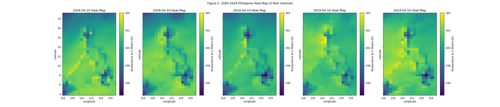

```python
file_geos_0410 = ('/mnt/data/public/power-datastore/v9/daily/2024/04/'
                  'power_901_daily_20240410_geos5124_utc.nc')
data_geos_0410 = xr.open_mfdataset(file_geos_0410,
                                   parallel=True,
                                   chunks={'time': 'auto',
                                           'lat': 'auto',
                                           'lon': 'auto'},
                                   engine='netcdf4')

file_merra_0410 = ('/mnt/data/public/power-datastore/v9/daily/20[01][49]/04/'
                   'power_901_daily_20??0410_merra2_utc.nc')
data_merra_0410 = xr.open_mfdataset(file_merra_0410,
                                    parallel=True,
                                    chunks={'time': 'auto',
                                            'lat': 'auto',
                                            'lon': 'auto'},
                                    engine='netcdf4')

fig, axs = plt.subplots(1, 5, figsize=(28, 6), sharey=True)
for idx in range(len(data_merra_0410['time'])):
    date = str(data_merra_0410['time'].isel(time=idx).values)[:10]
    (data_merra_0410['T2M'].isel(time=idx)
     .sel(lon=slice(116, 127), lat=slice(4, 21))
     .plot(ax=axs[idx], vmax=304.01, vmin=294.60))
    axs[idx].set_title(f'{date} Heat Map')
    axs[idx].set_xlabel('Longitude')
    axs[idx].set_ylabel('Latitude')

date = str(data_geos_0410['time'].isel(time=0).values)[:10]
(data_geos_0410['T2M'].isel(time=0)
 .sel(lon=slice(116, 127), lat=slice(4, 21))
 .plot(ax=axs[4], vmax=304.01, vmin=294.60))
axs[4].set_title(f'{date} Heat Map')
axs[4].set_xlabel('Longitude')
axs[4].set_ylabel('Latitude')
fig.suptitle('Figure 2. 2004-2024 Philippine Heat Map (5-Year Interval)')
plot_to_html('Figure 2. 2004-2024 Philippine Heat Map (5-Year Interval)')
```

The silhouette of the Philippines is visible in **Figure 2**. The waters surrounding the location are also included in the range and have their own observed temperatures. One commonality is that the higher temperatures have a tendency to appear on the area where the land surface would be. This is ideal for the study as the problem statement is primarily concerned in capturing the temperatures felt or perceived by Filipinos.

Comparing the five years against each other however, it cannot be concluded that temperatures have been increasing. This is expected as each plot only captures the average temperature over a location during a single day.

## 8.2 Yearly Temperature Comparison

To capture a better overview on how temperatures change over time, the observed metrics can be plotted daily across the 20-year period in a time series. As a pre-requisite, the data must first be aggregated on a per day basis, as the current dataset has each date represented by multuple values. The chosen aggregation period is to select the maximum value to represent each day, due to the following reasons:

- The multiple values under one date each signify the observed parameter captured within a specific location, as seen in the geographical heat maps generated in the previous section. As a result, the water-masses surrounding the Philippines land area is also captured. This would make averging as an unsuitable aggregation method for this use case as it may be skewed by the temperatures observed over the non-land areas.
- With the max chosen, the temperature for each day is represented by the location that is experiencing the highest average temperature for that day. Because the focus of the study is concerned with high temperatures, capturing the location experiencing the most extreme value (averaged across the whole day) would be suitable for the use case.

##### Table 17. Snapshot of 2004-2024 POWER Daily Data

```python
sdf_power_daily = (sdf_power
                   .groupby('time')
                   .max()
                  )
for column in sdf_power_daily.columns:
    if 'max(' in column:
        sdf_power_daily = (sdf_power_daily
                           .withColumnRenamed(
                               column,
                               (column.replace('max(', '').replace(')', ''))))
sdf_power_daily.cache()

apply_header_style((sdf_power_daily
 .limit(5)
 .toPandas()
))
```

|  | time | t2m | t2m_max | t2m_min | t2m_range | t2mdew | t2mwet | qv2m | qv10m | rh2m | troppb | tropq | tropt | u2m | u10m | u50m | v2m | v10m | v50m | ws2m | ws10m | ws50m | cdd0 | cdd10 | cdd18_3 | hdd0 | hdd10 | hdd18_3 | frseaice | … |
| --- | --- | --- | --- | --- | --- | --- | --- | --- | --- | --- | --- | --- | --- | --- | --- | --- | --- | --- | --- | --- | --- | --- | --- | --- | --- | --- | --- | --- | --- | --- |
| 0 | 2004-01-01 00:00:00 | 301.195312 | 304.578125 | 301.039062 | 10.539062 | 298.382812 | 299.664062 | 0.020020 | 0.019653 | 93.562500 | 10051.500000 | 0.000000 | 191.992188 | 1.734375 | 1.953125 | 2.046875 | 0.507812 | 0.546875 | 0.617188 | 7.882812 | 9.296875 | 10.507812 | 28.000000 | 18.000000 | 9.750000 | 0.000000 | 0.000000 | 0.000000 | 0.000000 | … |
| 1 | 2004-01-02 00:00:00 | 301.312500 | 304.343750 | 301.148438 | 11.171875 | 298.015625 | 299.460938 | 0.019592 | 0.019226 | 93.687500 | 11288.125000 | 0.000000 | 192.468750 | 2.523438 | 2.820312 | 3.015625 | 1.343750 | 1.500000 | 1.593750 | 8.000000 | 9.484375 | 10.882812 | 28.125000 | 18.125000 | 9.875000 | 0.000000 | 0.000000 | 0.000000 | 0.000000 | … |
| 2 | 2004-01-03 00:00:00 | 301.125000 | 304.828125 | 300.656250 | 11.171875 | 298.343750 | 299.656250 | 0.019958 | 0.019470 | 92.375000 | 11043.812500 | 0.000000 | 191.460938 | 1.039062 | 1.195312 | 1.250000 | 1.218750 | 1.320312 | 1.367188 | 9.195312 | 10.953125 | 12.500000 | 27.875000 | 17.875000 | 9.562500 | 0.000000 | 0.000000 | 0.000000 | 0.000000 | … |
| 3 | 2004-01-04 00:00:00 | 301.117188 | 305.187500 | 300.976562 | 13.382812 | 298.125000 | 299.382812 | 0.019714 | 0.019287 | 93.875000 | 11643.937500 | 0.000000 | 192.929688 | 1.085938 | 1.226562 | 1.265625 | 1.007812 | 1.179688 | 1.359375 | 8.570312 | 10.179688 | 11.617188 | 27.937500 | 17.937500 | 9.625000 | 0.000000 | 0.000000 | 0.000000 | 0.000000 | … |
| 4 | 2004-01-05 00:00:00 | 301.187500 | 305.515625 | 300.968750 | 10.570312 | 298.125000 | 299.562500 | 0.019653 | 0.019226 | 94.375000 | 9376.250000 | 0.000000 | 192.382812 | 1.593750 | 1.812500 | 1.898438 | 0.562500 | 0.648438 | 0.781250 | 7.546875 | 8.890625 | 10.078125 | 28.062500 | 18.062500 | 9.750000 | 0.000000 | 0.000000 | 0.000000 | 0.000000 | … |

The results of the aggregated data is detailed in **Table 17.**, with each day represented by a single row entry.

```python
print(f'Shape of the DataFrame: '
      f'({sdf_power_daily.count()}, {len(sdf_power_daily.columns)})')
```

```
Shape of the DataFrame: (7422, 31)
```

Checking the shape of the Spark DataFrame, the dataset is confirmed to be small enough to be transformed and saved as a Pandas DataFrame and allows for use of `matplotlib` for the remainder of the Descriptive Analytics section.

With the data aggregated on a daily basis, a time series can be plotted across the 20-year period.

```python
pdf_power_daily = sdf_power_daily.toPandas()
```

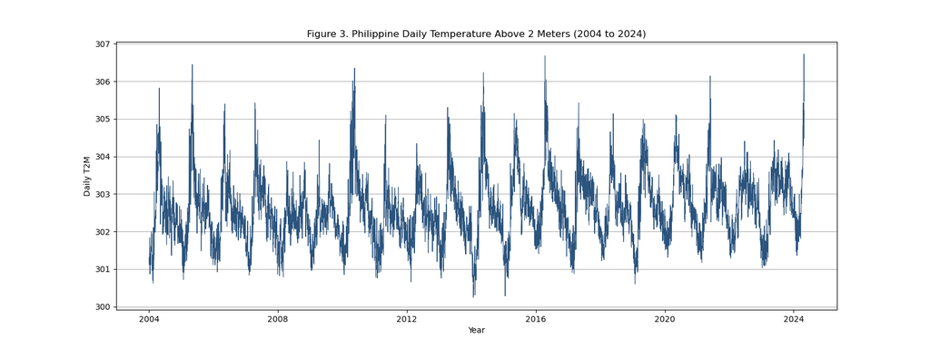

```python
plt.figure(figsize=(16, 6))
plt.plot(pdf_power_daily['time'],
         pdf_power_daily['t2m'],
         linestyle='-', c='#2B547E', lw=0.75)
plt.xlabel('Year')
plt.ylabel('Daily T2M')
plt.title('Figure 3. Philippine Daily Temperature Above 2 Meters '
          '(2004 to 2024)')
plt.grid(axis='y')
plot_to_html('Figure 3. Philippines Temperature Above 2 Meters '
             '(2004 to 2024)')
```

Visually, there is no immediate increasing trend that can be identified in **Figure 3.**. There is an implied seasonality, with peaks occuring around the first half of the year, and reaching its lowest points around the end and start of each year. Given the seasonality, data can be compared by looking at values of each month against each other on an annual basis. To implement this comparison, the data must further be aggregated on the monthly basis. The average of the entire month is chosen as the aggregation method. One reason is due to the volatility that comes with choosing extreme values such as the minimum or maximum to represent an entire month. Additionally, since the daily values have been aggregated on the assumption that they are located on top of the land area, taking the average across the entire month with these values should be safe as it won't contain observed values over water masses.

##### Table 18. Snapshot of 2004-2024 POWER Monthly Data

```python
sdf_power_monthly = (sdf_power_daily
                     .withColumn('date', sdf_power_daily['time'].cast('date'))
                     .groupby(year('date').alias('year'),
                              month('date').alias('month'))
                     .avg()
                     .orderBy('year', 'month')
                    )

for column in sdf_power_monthly.columns:
    if 'avg(' in column:
        sdf_power_monthly = (sdf_power_monthly
                             .withColumnRenamed(column,
                                                (column
                                                 .replace('avg(', '')
                                                 .replace(')', ''))))
sdf_power_monthly.cache()

pdf_power_monthly = sdf_power_monthly.toPandas()
apply_header_style((pdf_power_monthly
 .head(5)
))
```

|  | year | month | t2m | t2m_max | t2m_min | t2m_range | t2mdew | t2mwet | qv2m | qv10m | rh2m | troppb | tropq | tropt | u2m | u10m | u50m | v2m | v10m | v50m | ws2m | ws10m | ws50m | cdd0 | cdd10 | cdd18_3 | hdd0 | hdd10 | hdd18_3 | … |
| --- | --- | --- | --- | --- | --- | --- | --- | --- | --- | --- | --- | --- | --- | --- | --- | --- | --- | --- | --- | --- | --- | --- | --- | --- | --- | --- | --- | --- | --- | --- |
| 0 | 2004 | 1 | 301.385081 | 305.217994 | 301.045363 | 11.529990 | 298.179688 | 299.548891 | 0.019775 | 0.019342 | 93.262097 | 10738.310484 | 0.000001 | 194.323085 | 1.100050 | 1.211442 | 1.237147 | 1.200101 | 1.419607 | 1.712954 | 8.699849 | 10.294859 | 11.603075 | 28.308468 | 18.308468 | 10.010081 | 0.000000 | 0.000000 | 0.131048 | … |
| 1 | 2004 | 2 | 301.288793 | 306.279095 | 300.839709 | 12.110722 | 298.106412 | 299.435075 | 0.019704 | 0.019281 | 93.476293 | 11426.681034 | 0.000000 | 193.684537 | 2.061422 | 2.321121 | 2.500000 | 1.665679 | 1.980873 | 2.313308 | 8.834860 | 10.481142 | 11.854256 | 28.508621 | 18.508621 | 10.211207 | 0.000000 | 0.000000 | 0.150862 | … |
| 2 | 2004 | 3 | 302.824849 | 309.670867 | 301.471774 | 14.010081 | 298.469506 | 299.901714 | 0.020173 | 0.019742 | 93.840726 | 10764.796371 | 0.000000 | 192.202621 | 2.742440 | 3.111643 | 3.370212 | 2.277470 | 2.609627 | 2.896673 | 8.060988 | 9.543347 | 10.798387 | 30.108871 | 20.108871 | 11.810484 | 0.000000 | 0.000000 | 0.000000 | … |
| 3 | 2004 | 4 | 304.044271 | 311.350000 | 302.530990 | 15.310677 | 298.535937 | 300.358594 | 0.020229 | 0.019729 | 93.062500 | 11089.708333 | 0.000003 | 196.138802 | 2.827083 | 3.227083 | 3.500781 | 2.802344 | 3.173177 | 3.467708 | 6.929688 | 8.111198 | 9.122917 | 31.570833 | 21.570833 | 13.277083 | 0.000000 | 0.000000 | 0.000000 | … |
| 4 | 2004 | 5 | 303.433216 | 308.270161 | 302.625756 | 11.762097 | 299.401462 | 300.893649 | 0.021325 | 0.020866 | 94.207661 | 11600.685484 | 0.000004 | 196.086946 | 5.170111 | 6.076361 | 6.866431 | 5.974798 | 7.061996 | 7.999496 | 8.517641 | 10.168095 | 11.623740 | 30.627016 | 20.627016 | 12.322581 | 0.000000 | 0.000000 | 0.000000 | … |

The results of the aggregation is found in **Table 18.** With the values aggregated monthly, each year can be plotted against each other to compare each month year-on year. Each year is represented by a lineplot, with earlier years with a blue color-way, and more recent year assigned to red.

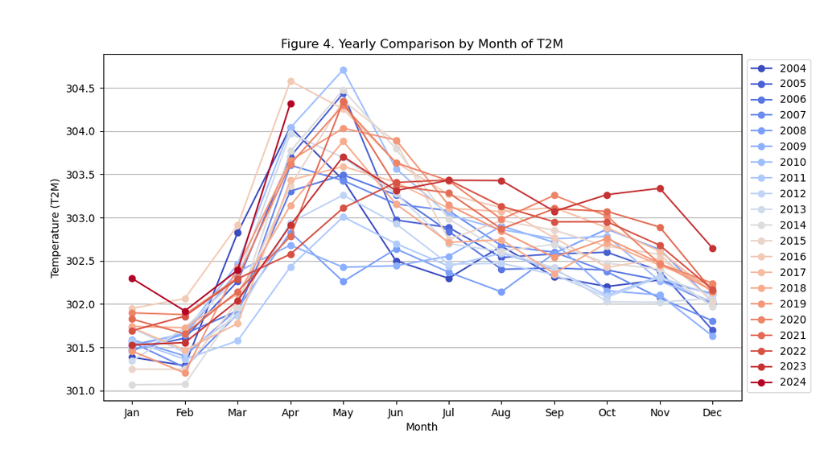

```python
lst_years = pdf_power_monthly['year'].unique()
cmap = cm.get_cmap('coolwarm')

plt.figure(figsize=(11, 6))
for idx, year in enumerate(lst_years):
    t2m_monthly = (pdf_power_monthly[pdf_power_monthly['year'] == year]
                   .groupby('month')['t2m'].mean())
    plt.plot(t2m_monthly.index,
             t2m_monthly.values,
             marker='o',
             label=f'{year}',
             color=cmap(np.linspace(0, 1, len(lst_years)))[idx])

plt.title(f'Figure 4. Yearly Comparison by Month of T2M')
plt.xlabel('Month')
plt.ylabel('Temperature (T2M)')
plt.xticks(range(1, 13), ['Jan', 'Feb', 'Mar', 'Apr', 'May', 'Jun',
                          'Jul', 'Aug', 'Sep', 'Oct', 'Nov', 'Dec'])
plt.legend(bbox_to_anchor=(1, 1), loc='upper left')
plt.grid(axis='y')
plot_to_html('Figure 4. Yearly Comparison by Month of T2M')
```

Looking at **Figure 4.**, seasonality can be visually identified, with peak temperatures starting during April and either continuing or increasing during the month of May. For trends, it's hard to say that the later years represented in red are inherently warmer or increasing in comparison to the earlier blue years, even during the peak summer months. However, looking at the second half of the year starting from July, the upper areas are dominated by red lines from the later years. There is some implication that there is a trend of each year gradually becoming warmer during what would usually be classified as the colder months such as December to February.

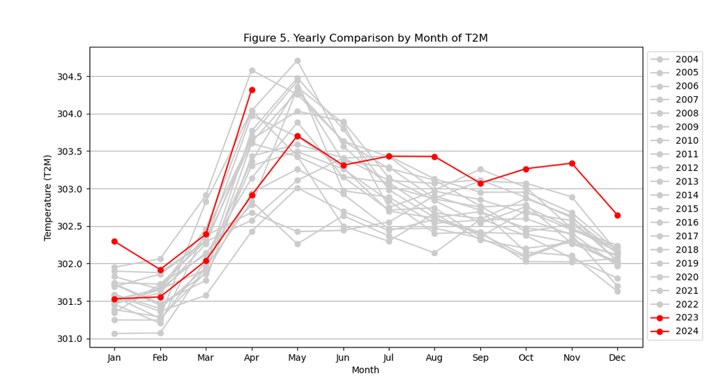

```python
lst_years = pdf_power_monthly['year'].unique()
cmap = cm.colors.ListedColormap([(0.8, 0.8, 0.8) if year < 2023
                                 else 'red' for year in lst_years])

plt.figure(figsize=(11, 6))
for idx, year in enumerate(lst_years):
    t2m_monthly = (pdf_power_monthly[pdf_power_monthly['year'] == year]
                   .groupby('month')['t2m'].mean())
    plt.plot(t2m_monthly.index,
             t2m_monthly.values,
             marker='o',
             label=f'{year}',
             color=cmap(idx))

plt.title(f'Figure 5. Yearly Comparison by Month of T2M')
plt.xlabel('Month')
plt.ylabel('Temperature (T2M)')
plt.xticks(range(1, 13), ['Jan', 'Feb', 'Mar', 'Apr', 'May', 'Jun',
                          'Jul', 'Aug', 'Sep', 'Oct', 'Nov', 'Dec'])
plt.legend(bbox_to_anchor=(1, 1), loc='upper left')
plt.grid(axis='y')
plot_to_html('Figure 5. Yearly Comparison by Month of T2M')
```

The plot can be configure to take a focused look on the most recent years, 2023 and 2024, in **Figure 5.** While the temperatures were relatively average during the first half of 2023 in terms of standards across the two decades, by the second half of the year, temperatures were consistently the highest of amongst the top three highest versus the past 20 years. 2024 did not start any better, with Januray recording the highest average versus the past two decades, and within the top 3 highest temperatures for the remaining three months.

## 8.3 Time Series Analysis

The Time Series Analysis section is split into two parts. First, seasonal decomposition is conducted to break down the time series into three components: trend, seasonality and residuals. Afterwards, statistical tests can be utilized to determine if there exists an increasing trend and if they have statistical significance.

### 8.3.1 Seasonal Decomposition

- Seasonal: represents the repeating patterns or cycles occuring in fixed intervals.
- Trend: Long-term upward or downward movement, ignoring short-term fluctuations.
- Residual: Remaining variation upon removal of the seasonal and trend components.

The study is focused on how seasonal decomposition plots the trend line, and if there is an upward movement that can be identified.

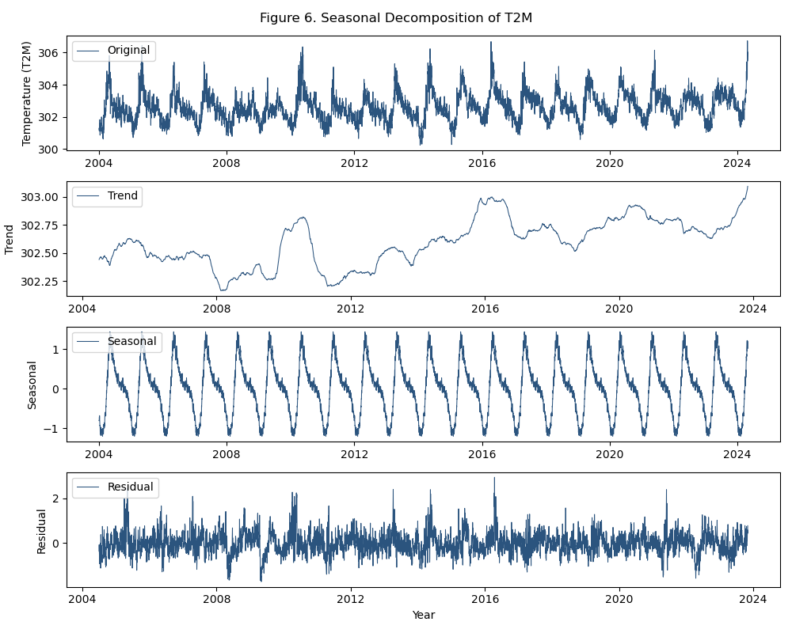

```python
result_sd = seasonal_decompose(pdf_power_daily['t2m'],
                               model='additive',
                               period=365)
c = '#2B547E'
fig, axs = plt.subplots(4, 1, figsize=(10, 8))
axs[0].plot(pdf_power_daily['time'], pdf_power_daily['t2m'],
            label='Original',  c=c, lw=0.75)
axs[0].legend(loc='upper left')
axs[0].set_ylabel('Temperature (T2M)')
axs[1].plot(pdf_power_daily['time'], result_sd.trend,
            label='Trend', c=c, lw=0.75)
axs[1].legend(loc='upper left')
axs[1].set_ylabel('Trend')
axs[2].plot(pdf_power_daily['time'], result_sd.seasonal,
            label='Seasonal', c=c, lw=0.75)
axs[2].legend(loc='upper left')
axs[2].set_ylabel('Seasonal')
axs[3].plot(pdf_power_daily['time'], result_sd.resid,
            label='Residual', c=c, lw=0.75)
axs[3].legend(loc='upper left')
axs[3].set_ylabel('Residual')
fig.suptitle(f'Figure 6. Seasonal Decomposition of T2M')
plt.xlabel('Year')
plt.tight_layout(rect=[0, 0, 1, 1])
plot_to_html('Figure 6. Seasonal Decomposition of T2M')
```

The trends can also be observed for the maximum (`t2m_max`), minimum (`t2m_min`) and Wet-bulb temperatures (`t2mwet`).

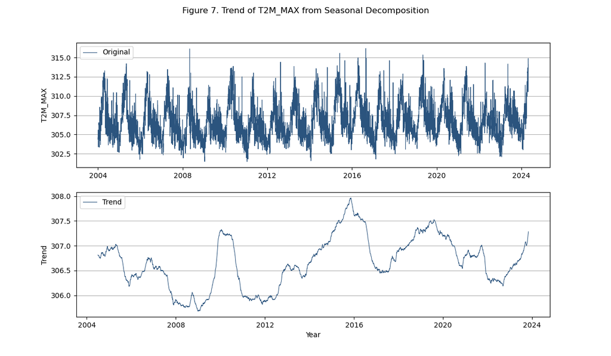

```python
plot_trend(pdf_power_daily, 't2m_max', 7)
```

Viewing **Figure 7.**, it is difficult to conclude visually that there is a strong upwards trend when looking at the maximum temperatures per day. This is likely due to maximum temperatures encompassing exceptional or anomalous events, resulting in a trend line that is more volatile.

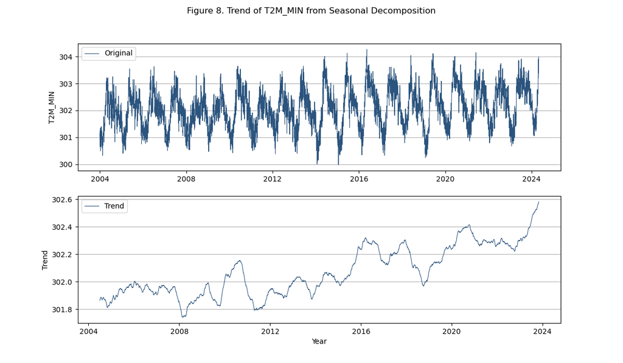

```python
plot_trend(pdf_power_daily, 't2m_min', 8)
```

**Figure 8.** displays the trend of the minimum daily temperature observed daily. The trend is more inherent here compared to the previous plots, with a stronger upward trend. The result implies that even the "coolest" temperatures being felt don't go quite as low as previous years.

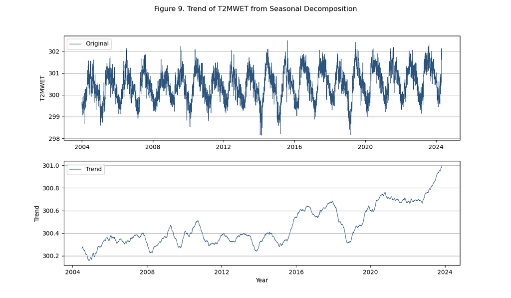

```python
plot_trend(pdf_power_daily, 't2mwet', 9)
```

Lastly, **Figure 9.** shows the trend line for the wet-bulb temperature or `t2mwet`, defined as the temperature measured from a thermometer covered in a water-soaked cloth. This can also translate to the wet-bulb temperature being equal to air temperature during 100% relative humidity. With higher wet-bulb temperatures, it can lead to discomfort or even health concerns due to the lessened evaporative cooling such as sweating that could be achieved by a person trying to cool themselves when experiencing high heat ("Wet-bulb temperature", n.d.).

Similar to the minimum daily temperataure, the wet-bulb temperatures display an increasing trend, mostly starting from 2016 onwards, reaching its peak at 2024. This could be translated to increased discomfort and lessened efficiency in evaporative cooling over the past few years, with the worse occuring during 2023 and 2024 so far.

### 8.3.2 Mann-Kendall Statistical Test for Trend Analysis

#### 8.3.2.1 Temperature Analysis

The significance of the trends plotted in the Seasonal Decomposition section can be confirmed through conducting statistical tests. For this study, the Mann-Kendall Statistical Test is used, a non-parametric test commonly used for trend analysis on climate data, which typically have non-normal distributions and outliers. The Mann-Kendall Test works well for the dataset as it makes no assumptions on the distribution, and is less sensitive to noise and skewed distributions (National Center for Atmospheric Research Staff [NCAR], 2014).

The null and alternate hypothesis are as follows:

- H<sub>0</sub> : There is no monotonic trend.
- H<sub>1</sub> : A monotonic trend is present.

The `alpha` or threshold is set to the default 0.05. To confirm the statistical significance of the trend, the null hypothesis is rejected should the p-value be less than `alpha` or 0.05 (Pacific Northwest National Laboratory, n.d.).

The `Cubic Polynomial Line Fit` is a curve-fitting process that finds a function to model data. The function does not necessarily pass through any of the points but aims to model the data with the smallest possible error. This method is used as a visual aid to help understand the non-linear increasing trend in the following time series data (MATLAB, n.d.)

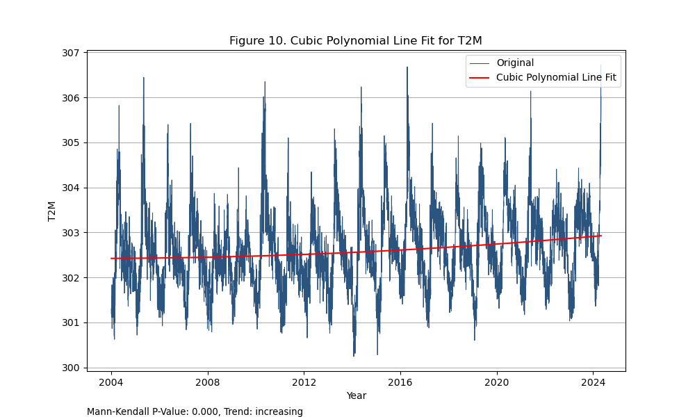

```python
plot_cubic_poly_mk(pdf_power_daily, 't2m', 10)
```

**Figure 10.** displays the original time series, overlaid by the cubic polynomial line fit of the series, and the results of the Mann-Kendall test and the corresponding computed p-value. The plot measured `t2m` or the air temperature observed 2 meters above ground. According to the results of the Mann-Kendall test, there is a stastically significant increasing or upward trend for `t2m` across the 20-year period. The same test can be applied to the other temperature-related metrics.

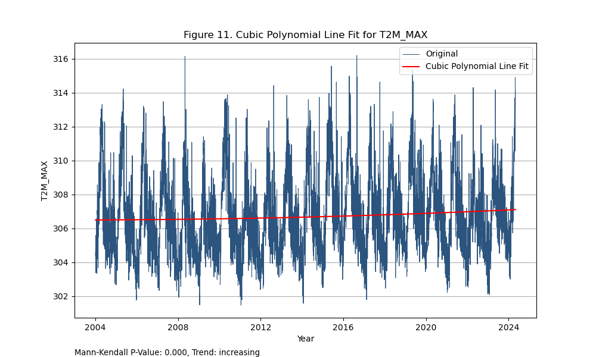

```python
plot_cubic_poly_mk(pdf_power_daily, 't2m_max', 11)
```

Applying the test to the maximum daily temperature, the trend is not as strong in comparison to the previous example, as visualized in the cubic polynomial line fit in **Figure 11.** The `p-value` measured is still less than 0.05, therefore the trend is concluded to be significant and increasing.

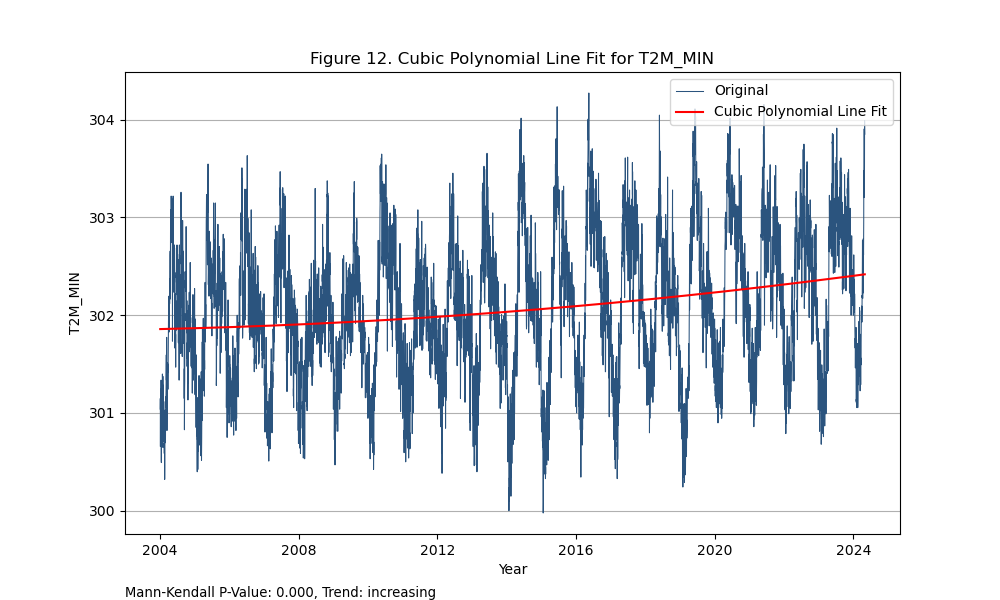

```python
plot_cubic_poly_mk(pdf_power_daily, 't2m_min', 12)
```

The cubic polynomial line fit for the minimum daily temperature in **Figure 12.** is much more prominent in terms of its increasing trend, and the results of the Mann-Kendall test confirm this as well, with a `p-value` less than 0.05.

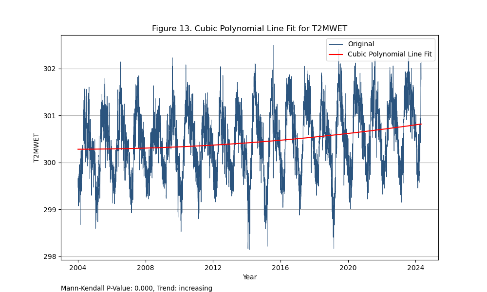

```python
plot_cubic_poly_mk(pdf_power_daily, 't2mwet', 13)
```

Similar results can be seen in the captured wet-bulb temperature in **Figure 13.**, with an increasing trend and a `p-value` of less than the `alpha`.

In summary, the 2-meter air temperature, minimium and maximum temperatures, and wet-bulb temperatures are confirmed to have statistically significant increasing or upward trends, when capturing the time series from 2004 to 2024.

#### 8.3.2.2 Heat Index Analysis

Another aspect that can be explored is the heat index, or the apparent temperature that can be described as the approximation of what the temperature "feels like" or is perceived by people. This heat index is typically higher as the relative humidity increases as it impacts the body's ability to cool itself. The formula used to calculate heat index is as follows:

$$HI = c_1 + c_2 T + c_3 R + c_4 TR + c_5 T^2 + c_6 R^2 + c_7 T^2 R + c_8 TR^2 + c_9 T^2 R^2$$

where:

- $HI$ = heat index (in degrees Fahrenheit)
- $T$ = ambient dry-bulb temperature (in degrees Fahrenheit)
- $R$ = relative humidity (percentage value between 0 and 100)

**Coefficients:**

$$ \begin{aligned} c_1 &= -42.379, \\ c_2 &= 2.049\,015\,23, \\ c_3 &= 10.143\,331\,27, \\ c_4 &= -0.224\,755\,41, \\ c_5 &= -6.837\,83 \times 10^{-3}, \\ c_6 &= -5.481\,717 \times 10^{-2}, \\ c_7 &= 1.228\,74 \times 10^{-3}, \\ c_8 &= 8.5282 \times 10^{-4}, \\ c_9 &= -1.99 \times 10^{-6}. \end{aligned} $$

The heat index is calculated using the `t2m` or temperature 2-meters above the surface and the `rh2m` or relative humidity. Since the temperature is in degrees Kelvin, it can be converted to degrees Farenheit with the following formula: $$ (K - 273.15) \times \frac{9}{5} + 32 = °F $$

##### Table 19. Snapshot of Philippine POWER Data with Calculated Heat Index

```python
udf_calculate_heat_idx = udf(calculate_heat_idx, DoubleType())
sdf_power_heat_idx = (sdf_power
                      .withColumn('t2m_f', (col('t2m') - 273.15) * (9/5) + 32)
                      .withColumn('heat_idx',
                                  udf_calculate_heat_idx('t2m_f', 'rh2m'))
                     )
sdf_power_heat_idx.cache()

pdf_power_heat_idx = (sdf_power_heat_idx
                      .select('time', 't2m', 't2m_f', 'rh2m', 'heat_idx')
                      .toPandas())
apply_header_style(pdf_power_heat_idx.head())
```

|  | time | t2m | t2m_f | rh2m | heat_idx |
| --- | --- | --- | --- | --- | --- |
| 0 | 2004-01-01 00:00:00 | 296.359375 | 73.776875 | 89.812500 | 71.969488 |
| 1 | 2004-01-01 00:00:00 | 298.796875 | 78.164375 | 89.062500 | 80.865296 |
| 2 | 2004-01-01 00:00:00 | 300.132812 | 80.569063 | 86.750000 | 86.637956 |
| 3 | 2004-01-01 00:00:00 | 300.195312 | 80.681563 | 87.000000 | 86.982021 |
| 4 | 2004-01-01 00:00:00 | 299.914062 | 80.175313 | 90.187500 | 86.156625 |

Shown in **Table 19.** is the resulting converted temperature (from Kelvin to Farenheit) as `t2m_f` and its corresponding calculated heat index as `heat_idx`. To check for the daily trend and significance, the heat index must also be aggregated per day such date each date is represented by one value per metric. Similar to the aggregation for the temperature, the heat index is also aggregated based on the maximum captured average across that day as the representative point.

##### Table 20. Snapshot of Philippine Daily Heat Index and Temperature (Farenheit)

```python
pdf_power_daily_heat_idx = (pdf_power_heat_idx
                            .groupby('time')
                            .max()
                            .reset_index()
                            .drop(['t2m', 'rh2m'], axis=1))
apply_header_style(pdf_power_daily_heat_idx.head())
```

|  | time | t2m_f | heat_idx |
| --- | --- | --- | --- |
| 0 | 2004-01-01 00:00:00 | 82.481563 | 90.939877 |
| 1 | 2004-01-02 00:00:00 | 82.692500 | 90.479585 |
| 2 | 2004-01-03 00:00:00 | 82.355000 | 90.621465 |
| 3 | 2004-01-04 00:00:00 | 82.340938 | 89.376034 |
| 4 | 2004-01-05 00:00:00 | 82.467500 | 90.663539 |

The resulting daily aggregation is displayed in **Table 20.** The original temperature time series and its corresponding heat index can be plotted against each other in a time series plot.

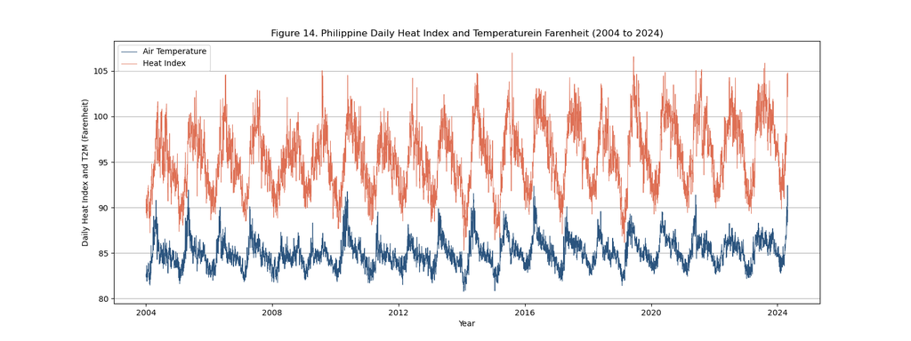

```python
plt.figure(figsize=(16, 6))
plt.plot(pdf_power_daily_heat_idx['time'],
         pdf_power_daily_heat_idx['t2m_f'],
         linestyle='-',
         lw=0.75,
         color='#2B547E',
         label='Air Temperature')
plt.plot(pdf_power_daily_heat_idx['time'],
         pdf_power_daily_heat_idx['heat_idx'],
         linestyle='-',
         color='#de6f54',
         lw=0.6,
         label='Heat Index')
plt.xlabel('Year')
plt.ylabel('Daily Heat Index and T2M (Farenheit)')
plt.legend()
plt.title('Figure 14. Philippine Daily Heat Index and Temperature'
          'in Farenheit (2004 to 2024)')
plt.grid(axis='y')
plot_to_html('Figure 14. Philippine Daily Heat Index and Temperature'
             'in Farenheit (2004 to 2024)')
```

**Figure 14.** plots the two time series against each other, and as expected, the heat index in general is higher compared to the air temperature. This is because of the high relative humidity experienced in the Philippines, causing the calculation of the heat index or the "feels-like" temperature to be higher versus the actual air temperature. Next, the Mann-Kendall Test can be conducted on the Heat Index to check for trends and if they are statistically significant.

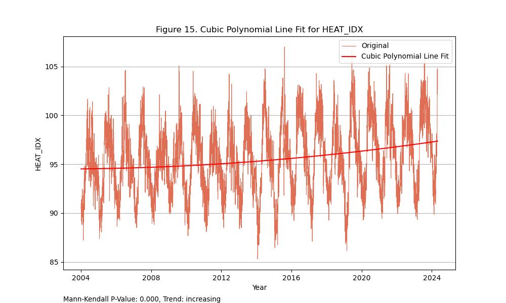

```python
plot_cubic_poly_mk(pdf_power_daily_heat_idx, 'heat_idx', 15)
```

The cubic polynomial line fit for the heat index in **Figure 15.** is shown to be trending upwards, and the trend is confirmed to be both increasing and statistically significant via the Mann-Kendall test results, with a `p-value` less than the `alpha` of 0.05. In summary, this means both actual air temperature as well as the "feels-like" or perceived temperature by a person has an upwards trend when measured over the past two decades in the Philippines.

## 8.4 Outlier Detection for Monthly Data

This analysis focuses on detecting outliers in the heat index within a 20-year dataset for the Philippines. Outliers are defined as values significantly deviating from typical patterns. The goal is to identify outlier months, which represent exceptional periods rather than individual days.

The study focuses on the fundamental features of temperature `t2m` and relative humidity `rh2m` which are the components for heat index. The temperature will be aggregated by calculating the maximum daily temperature, then averaging these maximum temperatures across each month. For relative humidity, this can be determined by exploring its distribution across the Philippines on a representative day chosen from the previously generated Geographical Heat Map, to ensure good representation of the land area.

### 8.4.1 Feature Monthly Aggregation

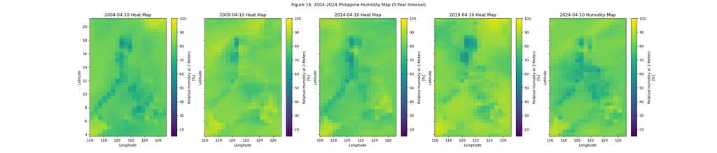

```python
fig, axs = plt.subplots(1, 5, figsize=(28, 6), sharey=True)
for idx in range(len(data_merra_0410['time'])):
    date = str(data_merra_0410['time'].isel(time=idx).values)[:10]
    (data_merra_0410['RH2M'].isel(time=idx)
     .sel(lon=slice(116, 127), lat=slice(4, 21))
     .plot(ax=axs[idx], vmax=100.00, vmin=15.10))
    axs[idx].set_title(f'{date} Heat Map')
    axs[idx].set_xlabel('Longitude')
    axs[idx].set_ylabel('Latitude')

date = str(data_geos_0410['time'].isel(time=0).values)[:10]
(data_geos_0410['RH2M'].isel(time=0)
 .sel(lon=slice(116, 127), lat=slice(4, 21))
 .plot(ax=axs[4], vmax=100.00, vmin=15.10))
axs[4].set_title(f'{date} Humidity Map')
axs[4].set_xlabel('Longitude')
axs[4].set_ylabel('Latitude')
fig.suptitle('Figure 16. 2004-2024 Philippine Humidity Map (5-Year Interval)')
plot_to_html('Figure 16. 2004-2024 Philippine Humidity Map (5-Year Interval)')
```

Based on the humidity map graphs in **Figure 16.**, the daily relative humidity should be aggregated via the minimum, as those are the values experienced over land mass. This is likely due to relatively humidity increasing over water masses. Afterwards, the relative humidity will be aggregated across the whole month by getting the average.

##### Table 21. Snapshot of Philippine Monthly Temperature and Relative Humidity

```python
from pyspark.sql.functions import year

sdf_power_monthly_out = (sdf_power
                         .groupby('time')
                         .agg(max(col('t2m')).alias('t2m'),
                              min(col('rh2m')).alias('rh2m'))
                         .withColumn('date',
                                     sdf_power_daily['time'].cast('date'))
                         .groupby(year('date').alias('year'),
                                  month('date').alias('month'))
                         .agg(avg(col('t2m')).alias('t2m'),
                              avg(col('rh2m')).alias('rh2m'))
                         .orderBy('year', 'month')
                        )
sdf_power_monthly_out.cache()

pdf_power_monthly_out = sdf_power_monthly_out.toPandas()
apply_header_style((pdf_power_monthly_out
 .head(5)
))
```

|  | year | month | t2m | rh2m |
| --- | --- | --- | --- | --- |
| 0 | 2004 | 1 | 301.385081 | 67.308468 |
| 1 | 2004 | 2 | 301.288793 | 65.872845 |
| 2 | 2004 | 3 | 302.824849 | 59.947581 |
| 3 | 2004 | 4 | 304.044271 | 55.387500 |
| 4 | 2004 | 5 | 303.433216 | 65.604839 |

Represented in **Table 21.** is the resulting aggregated temperature and relative humidity values for each month. These value pairs can be visualized in a plot

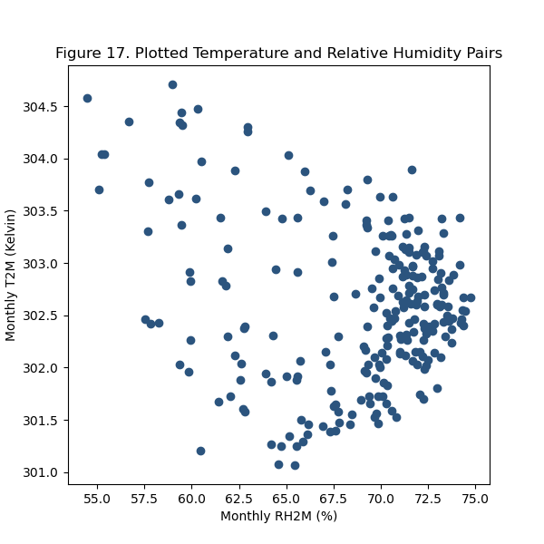

```python
plt.figure(figsize=(6, 6))
plt.scatter(pdf_power_monthly_out.loc[:, 'rh2m'],
            pdf_power_monthly_out.loc[:, 't2m'], c=c)
plt.xlabel('Monthly RH2M (%)')
plt.ylabel('Monthly T2M (Kelvin)')
plt.title('Figure 17. Plotted Temperature and Relative Humidity Pairs')
plot_to_html('Figure 17. Plotted Temperature and Relative Humidity Pairs')
```

Plotted in **Figure 17.** is another representation of the temperature-relative humidity pairs. The visualization is used to determine what outlier method to conduct.

### 8.4.3 Gaussian Mixture Model

#### 8.4.3.1 Standardization

In the context of the POWER NASA dataset, which contains features such as temperature and relative humidity, the Gaussian Mixture Model or GMM can be particularly useful. These features can come from more than one underlying distributions, and GMM's ability to model these distributions, even when they have nonlinearity or other complex characteristics, makes it a suitable choice for outlier detection or clustering this type of dataset. To initiate the modelling, standardization across the two features must be conducted due to their differing units of measurements.

##### Table 22. Snapshot of Philippine Monthly Temperature and Relative Humidity (Scaled)

```python
pdf_power_monthly_out_copy = pdf_power_monthly_out.copy()
pdf_power_monthly_out_copy.drop(['year', 'month'], axis=1, inplace=True)
scaler = StandardScalerSklearn()
X_scaled = scaler.fit_transform(pdf_power_monthly_out_copy)
pdf_power_monthly_scaled = pd.DataFrame(
    X_scaled,
    columns=pdf_power_monthly_out_copy.columns)
apply_header_style(pdf_power_monthly_scaled.head())
```

|  | t2m | rh2m |
| --- | --- | --- |
| 0 | -1.602490 | -0.265169 |
| 1 | -1.730189 | -0.569162 |
| 2 | 0.306971 | -1.823834 |
| 3 | 1.924203 | -2.789428 |
| 4 | 1.113804 | -0.625912 |

The results of standard scaling is displayed in **Table 22.**

#### 8.4.3.2 Distribution of the Log-likelihood

```python
model = mixture.GaussianMixture(n_components=1,
                                covariance_type='diag',
                                random_state=0)
model.fit(pdf_power_monthly_scaled);
```

Using the Gaussian Mixture Model, the GMM score can be computed. A higher score means a higher likelihood or probability that a certain datapoint belongs to a cluster versus not. Datapoints with low likelihood scores are likely outliers. The histogram distribution of the scores guides in choosing the appropriate threshold for the outliers.

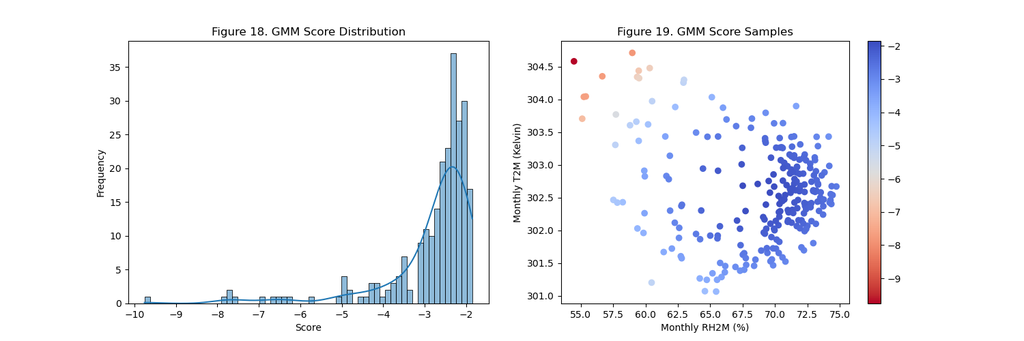

```python
plt.figure(figsize=(15, 5))

plt.subplot(1, 2, 1)
gmm_scores = model.score_samples(pdf_power_monthly_scaled)
sns.histplot(gmm_scores, bins=60, kde=True)
plt.title('Figure 18. GMM Score Distribution')
plt.xlabel('Score')
plt.ylabel('Frequency')

plt.subplot(1, 2, 2)
plt.scatter(pdf_power_monthly_out.loc[:, 'rh2m'],
            pdf_power_monthly_out.loc[:, 't2m'],
            c=gmm_scores,
            cmap='coolwarm_r')
plt.colorbar()
plt.xlabel('Monthly RH2M (%)')
plt.ylabel('Monthly T2M (Kelvin)')
plt.title('Figure 19. GMM Score Samples')
plot_to_html('Figure 18. GMM Score Distribution')
```

**Figure 18.** shows the Gaussian Mixture Model (GMM) to identify potential outliers in the data's score distribution. These outliers reside in the skewed tail, where data points are infrequent and deviate significantly from the central area, interquartile range. The accompanying scatter plot in **Figure 19.** highlights these potential outliers in red for further examination.

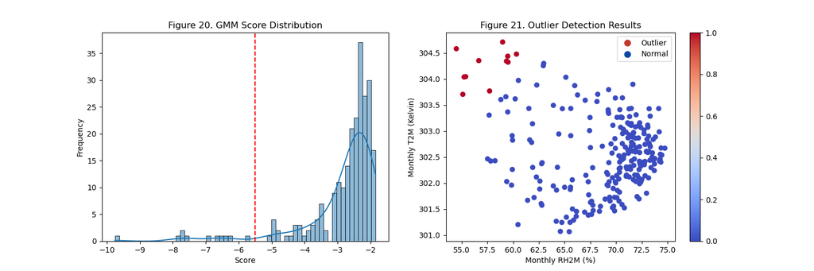

```python
thresh = -5.5

plt.figure(figsize=(15, 5))

plt.subplot(1, 2, 1)
gmm_scores = model.score_samples(pdf_power_monthly_scaled)
sns.histplot(gmm_scores, bins=60, kde=True)
plt.axvline(x=thresh, color='red', linestyle='--')
plt.title('Figure 20. GMM Score Distribution')
plt.xlabel('Score')
plt.ylabel('Frequency')

plt.subplot(1, 2, 2)
outliers_mask = (gmm_scores < thresh)
plt.scatter(pdf_power_monthly_out.loc[:, 'rh2m'],
            pdf_power_monthly_out.loc[:, 't2m'],
            c=np.where(outliers_mask, 1, 0),
            cmap='coolwarm')
plt.colorbar()
plt.xlabel('Monthly RH2M (%)')
plt.ylabel('Monthly T2M (Kelvin)')
plt.title('Figure 21. Outlier Detection Results')
legend_labels = ['Outlier', 'Normal']
plt.legend(
    handles=[plt.Line2D([0], [0], marker='o',
                        color='w', markerfacecolor='#C0392B',
                        markersize=10, label=legend_labels[0]),
    plt.Line2D([0], [0], marker='o', color='w',
               markerfacecolor='#0D47A1', markersize=10,
               label=legend_labels[1])])
plot_to_html('Figure 20. GMM Score Distribution')
```

##### Table 23. Outlier Year-Months and GMM Scores

```python
pdf_power_monthly_out['gmm_score'] = gmm_scores
pdf_power_monthly_out.sort_values('gmm_score', inplace=True)
pdf_outliers = (pdf_power_monthly_out[
                pdf_power_monthly_out['gmm_score'] < thresh]
                .reset_index())

apply_header_style(pdf_outliers)
```

|  | index | year | month | t2m | rh2m | gmm_score |
| --- | --- | --- | --- | --- | --- | --- |
| 0 | 147 | 2016 | 4 | 304.580469 | 54.475000 | -9.758435 |
| 1 | 76 | 2010 | 5 | 304.709425 | 58.979839 | -7.833589 |
| 2 | 136 | 2015 | 5 | 304.352067 | 56.661290 | -7.732395 |
| 3 | 75 | 2010 | 4 | 304.038281 | 55.235417 | -7.654700 |
| 4 | 3 | 2004 | 4 | 304.044271 | 55.387500 | -7.579606 |
| 5 | 15 | 2005 | 4 | 303.704427 | 55.110417 | -6.979301 |
| 6 | 16 | 2005 | 5 | 304.436492 | 59.475806 | -6.675735 |
| 7 | 124 | 2014 | 5 | 304.477067 | 60.324597 | -6.479116 |
| 8 | 208 | 2021 | 5 | 304.341986 | 59.356855 | -6.425992 |
| 9 | 243 | 2024 | 4 | 304.322917 | 59.506250 | -6.306511 |
| 10 | 123 | 2014 | 4 | 303.768750 | 57.712500 | -5.691161 |

The list of outliers months and their corresponding temperature, relative humidity and GMM score is found in **Table 23.**

### 8.4.5 Outlier Year-Month Matrix

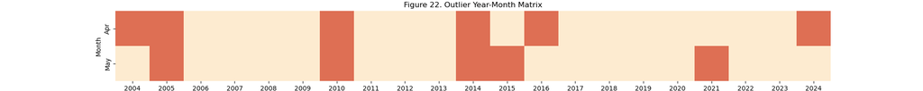

```python
outlier_matrix = (pdf_outliers[['year', 'month']]
                  .pivot_table(index='month',
                               columns='year',
                               aggfunc=lambda x: 1,
                               fill_value=0)
                  .reindex(columns=range(2004, 2024 + 1),
                           fill_value=0))
outlier_matrix.index = outlier_matrix.index.map(
    lambda x: calendar.month_abbr[x])

plt.figure(figsize=(20, 2))
sns.heatmap(outlier_matrix, cmap=['#FDEBD0', '#de6f54'], cbar=False)
plt.xlabel('Year')
plt.ylabel('Month')
plt.title('Figure 22. Outlier Year-Month Matrix')
plot_to_html('Figure 22. Outlier Year-Month Matrix')
```

While the recent years haven't seen a rise in outliers, **Figure 22.** shows that **April 2024 is an outlier**. Both temperature and relative humidity, key components for calculating the Heat Index, exhibit extreme values based on the GMM.

## 8.5 Correlation Matrix

A correlation matrix will explore how environmental features influence the Heat Index. This analysis aims to identify:

1. Key features significantly impacting perceived temperature (amplifying or mitigating heat).
2. Features with negligible impact on perceived heat.

By examining these relationships, a better understanding can be gained on how environmental variables affects the perceived temperature.

```python
sdf_power_corr = (sdf_power_heat_idx
                  .drop('t2m_f', 'time')
                 )
sdf_power_corr.cache()

assembler = VectorAssembler(inputCols=sdf_power_corr.columns,
                            outputCol='features')
sdf_power_assembled = assembler.transform(sdf_power_corr)
scaler_spark = StandardScalerSpark(inputCol='features',
                                   outputCol='scaled_features',
                                   withStd=True,
                                   withMean=True)
sdf_power_scaled = (scaler_spark
                    .fit(sdf_power_assembled)
                    .transform(sdf_power_assembled))
```

```python
corr_matrix = (Correlation
               .corr(sdf_power_scaled, 'scaled_features')
               .head()[0]
               .toArray())
sdf_corr_matrix = spark.createDataFrame(corr_matrix.tolist(),
                                        sdf_power_corr.columns)
sdf_corr_matrix.cache()

pdf_corr_matrix = sdf_corr_matrix.toPandas()
```

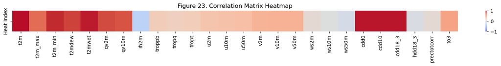

```python
plt.figure(figsize=(20, 0.75))
sns.heatmap((pdf_corr_matrix.loc[[30], :]
             .drop(['hdd0', 'hdd10', 'heat_idx', 'frseaice', 't2m_range'],
                   axis=1)),
            yticklabels=['Heat Index'],
            cmap='coolwarm',
            vmin=-1,
            vmax=1)
plt.title('Figure 23. Correlation Matrix Heatmap')
plt.show()
```

**Figure 23.** displays the results of the correlation matrix between the heat index and other relevant features.

# 9. Results and Discussion

**1. It is not the most wonderful time of the year.**

While there is no strong tendency for temperatures during later years (2016 onwards) to be higher compared to earlier years during the first half of each year (January to June), by the later half of the year, more recent years tended to be progressively warmer. This implies that while some recent year did not have as intense of a summer season during the months of April and May, the temperatures never went decreased much either. The concept of a "cold season" during Christmas and early January as a respite from the hot months seems to be slowly disappearing.

**2. Hot is the New "Cool".**

Breaking down the composition of the time series into its components, the trends for temperatures, although fluctuating, display relatively upward trends. Interestingly, the minimum temperatures have this obvious upward trend, insinuating that while the maximum or worse-case conditions vary year on year, the "respite" or cooler temperatures are gradually rising. In a way, while the worst comes and goes, it isn't getting any better either.

**3. Summer just got even hotter.**

Aside from temperatures trending upwards, April 2024 turned out to be an outlier year with exceptionally high temperatures and deviating relative humidity, intensifying the heat index. Additionally, it's interesting to note that outlier months always occur either during April or May. Not only are April and May the hottest months, but they also experience anomalies in the fundamental components of the heat index.

# 10. Conclusion

Over the past two decades, **temperatures have been increasing with a statistically significant upward trend**. Not only is **April 2024 much hotter** compared to previous recent years, but the years prior have been trending upwards for a while now. It is **indeed getting hotter in the Philippines.**

# 11. Recommendations

Several improvements could enhance the methodology and findings of future studies.

Firstly, extending the analysis beyond the 20-year time period considered could provide a more comprehensive understanding of long-term climate trends and cycles. This would help capture any nuances or patterns that may not be evident within a shorter time frame.

Secondly, while the use of daily data in the current study provides a broad overview of temperature trends, incorporating hourly data could offer a more detailed analysis of temperature variability on shorter time scales. This finer granularity could reveal important insights into how temperatures fluctuate throughout the day and how they respond to different environmental factors.

Thirdly, further specificity on the longitude and latitude ranges could have been added by excluding water area. This could potentially be achieved by integrating this dataset with the geographic shape files of the Philippines.

Additionally, expanding the research to include other countries, such as those in Southeast Asia or globally, could provide a broader perspective on climate trends and patterns. This comparative analysis could help identify similarities and differences in climate behavior across regions.

Lastly, future studies could benefit from exploring the use of Sedona with PySpark for geospatial analysis and comparing its performance with Xarray. This comparative analysis could provide valuable insights into the most effective tool for specific geospatial analysis tasks, helping researchers make more informed decisions when analyzing climate data.

# 12. References

ABS-CBN News. (2024, May 3). Extreme heat reveals sunken town in the Philippines. ABS-CBN News. Retrieved from https://news.abs-cbn.com/regions/2024/5/3/extreme-heat-reveals-sunken-town-in-the-philippines-1140

BusinessWorld. (2024, May 2). DOH: 7 have died in Philippines due to record heat. BusinessWorld. Retrieved from https://www.bworldonline.com/the-nation/2024/05/02/592523/doh-7-have-died-in-philippines-due-to-record-heat/

Geography of the Philippines. (n.d.). In Wikipedia. Retrieved from https://en.wikipedia.org/wiki/Geography_of_the_Philippines

Heat index. (n.d.). In Wikipedia. Retrieved from https://en.wikipedia.org/wiki/Heat_index

Hoyer, S., Hamman, J., Forsythe, J., Rocklin, M., Smith, T., & Doutriaux, C. (n.d.). Xarray: I/O. Retrieved from https://docs.xarray.dev/en/stable/user-guide/io.html

Hyndman, R. J., & Athanasopoulos, G. (2022). Forecasting: Principles and Practice. OTexts.

Inquirer.net. (2024, April 29). Hot, hot, hot: Clark area heat index hits 50°C. Inquirer.net. Retrieved from https://newsinfo.inquirer.net/1937535/hot-hot-hot-clark-area-heat-index-hits-50c

MATLAB®: An Introduction with Applications, Fourth Edition. (n.d.). O’Reilly Online Learning. https://www.oreilly.com/library/view/matlab-an-introduction/9780470767856/ch08.html

NASA. (n.d.). NASA POWER. Retrieved from https://registry.opendata.aws/nasa-power/

NASA Earth Observatory. (n.d.). MODIS Land Surface Temperature and NDVI. Retrieved from https://earthobservatory.nasa.gov/global-maps/MOD_NDVI_M/MOD_LSTD_M

NASA Langley Research Center. (n.d.). NASA POWER Documentation. Retrieved from https://power.larc.nasa.gov/docs/

National Center for Atmospheric Research Staff (Eds.). (2014, September 5). The Climate Data Guide: Trend Analysis. Retrieved from https://climatedataguide.ucar.edu/climate-data-tools-and-analysis/trend-analysis.

Pacific Northwest National Laboratory. (n.d.). Mann-Kendall Trend Test. Retrieved from https://vsp.pnnl.gov/help/Vsample/Design_Trend_Mann_Kendall.htm

Rappler. (2024, May). Air conditioner at municipal health office in Pangasinan stolen in May 2024. Rappler. Retrieved from https://www.rappler.com/nation/luzon/air-conditioner-municipal-health-office-pangasinan-stolen-may-2024/

Reuters. (2024, April 29). Philippine students suffer wilting heat, thwarting education efforts. Reuters. Retrieved from https://www.reuters.com/world/asia-pacific/philippine-students-suffer-wilting-heat-thwarting-education-efforts-2024-04-29/

The New York Times. (2024, April 29). Schools are closing in the Philippines as the heat hits hard. The New York Times. Retrieved from https://www.nytimes.com/2024/04/29/world/asia/philippines-heat-schools-jeepney.html

The Philippine Star. (2024, May 4). Dangerous heat index expected in 30 areas nationwide, including NCR. Philippine Star. Retrieved from https://www.philstar.com/headlines/2024/05/04/2352571/dangerous-heat-index-expected-30-areas-nationwide-including-ncr

Wet-bulb temperature. (n.d.). In Wikipedia. Retrieved from https://en.wikipedia.org/wiki/Wet-bulb_temperature